# Mid Term Project - Technical Appendix

Sourabh Gupta

February 25, 2019

# 1 Goal of the EDA:

The goal of this EDA is to understand how effective in-store promos and ads are for General Mills products. This will help assess whether expenses on marketing efforts are yielding the required return.

# 2 Prerequisites for analysis

Following needs to be prior to any analysis:

- Clear your environment
- Load required packages
- Organize your work and point to the right directories

```r
# Clear environment of variables and functions
rm(list = ls(all = TRUE))

# Clear environment of packages
if(is.null(sessionInfo()$otherPkgs) == FALSE) {
  lapply(paste("package:", names(sessionInfo()$otherPkgs), sep=""),
         detach, character.only = TRUE, unload = TRUE)
}

# load required libraries (Use install.packages(tidyverse), for example, if needed)
library(tidyverse)
library(here)
library(skimr)
library(janitor)
library(gridExtra)
library(GGally)
library(knitr)
library(kableExtra)
library(pander)
library(formattable)
library(ggrepel)
library(scales)
library(psych)
```

Following needs to be done prior to starting an EDA:

- Load raw data
- Make changes to data based on business rules definitions
- Perform joins as required

```r
raw_data_product <- read_csv("mtp_product_data.csv")
raw_data_sales <- read_csv("mtp_sales_data.csv")

# separating producer and product name, because product name is combination of both

product <- raw_data_product %>%
  mutate(UPC = str_replace_all(str_sub(UPC, 4), "-", ""),
         brand_name = case_when(
           str_detect(brand, "GENERAL MILLS") ~ "General Mills",
           str_detect(brand, "KELLOGGS") ~ "Kelloggs",
           str_detect(brand, "POST") ~ "Post"),
         product_name = str_trim(
           str_to_title(
             str_replace(brand, toupper(brand_name), ""), "left")),
         flavor = str_to_title(flavor),
         package = str_to_title(package))

# defining columns based on whether promo, discounts and ads are run, for easier labeling in plots

sales <- raw_data_sales %>%
  mutate(UPC = str_replace_all(UPC, "\\.", ""),
         discount_offered = if_else(promo == 1, "Yes", "No"),
         promo = if_else(promo == 1, "With Promo", "Without Promo"),
         ad = case_when(ad == "A" ~ "Large",
                        ad == "B"~ "Medium or Small",
                        TRUE ~ "None"),
         promo_plus_ad = case_when(
           promo == "With Promo" & ad == "None" ~ "Promo",
           promo == "Without Promo" & ad != "None" ~ "Ad",
           promo != "Without Promo" & ad != "None" ~ "Both",
           TRUE ~ "None"
         ),
         sales = round(price * units, 2),
         quarter_nbr = ceiling(4 * week / 52)
         )

# joining the data

cereal <- left_join(product, sales) %>%
  rename(upc = UPC, store_nbr = iri_key, week_nbr = week) %>%
  mutate(upc = factor(upc),
         store_nbr = factor(store_nbr),
         brand_name = factor(brand_name),
         product_name = factor(product_name),
         flavor = factor(flavor),
         package = factor(package),
         discount_offered = factor(discount_offered),
         promo = factor(promo),
         ad = factor(ad),
         promo_plus_ad = factor(promo_plus_ad),
         week_nbr = factor(week_nbr),
         quarter_nbr = factor(quarter_nbr)
         ) %>%
  select(upc, brand_name, product_name, flavor, store_nbr,
         units, price, sales,
         everything()) %>%
  select(-brand)

# check the structure
str(cereal)
```

```
## Classes 'tbl_df', 'tbl' and 'data.frame':    21850 obs. of  16 variables:
##  $ upc             : Factor w/ 114 levels "011600011653",..: 1 1 1 1 1 2 2 2 2 2 ...
##  $ brand_name      : Factor w/ 3 levels "General Mills",..: 1 1 1 1 1 1 1 1 1 1 ...
##  $ product_name    : Factor w/ 15 levels "Cheerios","Cinnamon Tst Cr",..: 2 2 2 2 2 1 1 1 1 1 ...
##  $ flavor          : Factor w/ 5 levels "Cinnamon Toast",..: 1 1 1 1 1 5 5 5 5 5 ...
##  $ store_nbr       : Factor w/ 1420 levels "200171","200197",..: 1041 446 1018 1128 1018 1217 48 446 493 1050 ...
##  $ units           : int  5 2 3 10 10 2 8 5 14 4 ...
##  $ price           : num  0.5 0.5 0.5 0.5 0.5 0.5 0.5 0.5 0.5 0.5 ...
##  $ sales           : num  2.5 1 1.5 5 5 1 4 2.5 7 2 ...
##  $ volume          : num  0.06 0.06 0.06 0.06 0.06 0.04 0.04 0.04 0.04 0.04 ...
##  $ package         : Factor w/ 2 levels "Box","Cup": 1 1 1 1 1 1 1 1 1 1 ...
##  $ week_nbr        : Factor w/ 52 levels "1","2","3","4",..: 6 5 11 13 16 11 13 14 2 3 ...
##  $ promo           : Factor w/ 2 levels "With Promo","Without Promo": 2 2 2 2 2 2 2 2 2 2 ...
##  $ ad              : Factor w/ 3 levels "Large","Medium or Small",..: 1 3 3 3 3 3 3 3 3 3 ...
##  $ discount_offered: Factor w/ 2 levels "No","Yes": 1 1 1 1 1 1 1 1 1 1 ...
##  $ promo_plus_ad   : Factor w/ 4 levels "Ad","Both","None",..: 1 3 3 3 3 3 3 3 3 3 ...
##  $ quarter_nbr     : Factor w/ 4 levels "1","2","3","4": 1 1 1 1 2 1 1 2 1 1 ...
```

**Conclusions:**

- Brand name, product name, flavor seems very useful for study the variation among different combination
- Package, promo ad, discount offered, promo and ad combined are useful to study the different effect on products
- quarter number is useful to study the result in different quarters of the year
- Price per unit tells us the price of each product per unit, so we will be able to compare the price between different brands

# 3 Summary of data

We look at a summary of data:

- to know how clean the data is
- to check if typical values (in the middle or at extremes) make sense
- to confirm if there missing values that need to be addressed

The **skim** function in the **skimr** package summarises columns separately by data type - (here) factor variables followed by integers and numerics

```r
# knitr.auto.asis splits table
# kable renders long format table

# panderOptions('knitr.auto.asis', FALSE)
# skim(cereal) %>% pander()

# skim(cereal) %>% kable() %>% kable_styling()

panderOptions('table.split.table', Inf)
skim(cereal) %>% pander()
```

Skim summary statistics  
n obs: 21850  
n variables: 16

| variable | missing | complete | n | n_unique | top_counts | ordered |
| --- | --- | --- | --- | --- | --- | --- |
| ad | 0 | 21850 | 21850 | 3 | Non: 19333, Lar: 1456, Med: 1061, NA: 0 | FALSE |
| brand_name | 0 | 21850 | 21850 | 3 | Kel: 12183, Gen: 7189, Pos: 2478, NA: 0 | FALSE |
| discount_offered | 0 | 21850 | 21850 | 2 | No: 17305, Yes: 4545, NA: 0 | FALSE |
| flavor | 0 | 21850 | 21850 | 5 | Reg: 8816, Toa: 7107, Fru: 2192, Coc: 1901 | FALSE |
| package | 0 | 21850 | 21850 | 2 | Box: 21306, Cup: 544, NA: 0 | FALSE |
| product_name | 0 | 21850 | 21850 | 15 | Fro: 2295, Fro: 2192, Cin: 1834, Luc: 1681 | FALSE |
| promo | 0 | 21850 | 21850 | 2 | Wit: 17305, Wit: 4545, NA: 0 | FALSE |
| promo_plus_ad | 0 | 21850 | 21850 | 4 | Non: 16220, Pro: 3113, Bot: 1432, Ad: 1085 | FALSE |
| quarter_nbr | 0 | 21850 | 21850 | 4 | 3: 5533, 4: 5478, 2: 5475, 1: 5364 | FALSE |
| store_nbr | 0 | 21850 | 21850 | 1420 | 656: 35, 256: 31, 259: 31, 267: 31 | FALSE |
| upc | 0 | 21850 | 21850 | 114 | 014: 676, 013: 666, 013: 660, 011: 639 | FALSE |
| week_nbr | 0 | 21850 | 21850 | 52 | 22: 475, 12: 473, 37: 464, 29: 449 | FALSE |

| variable | missing | complete | n | mean | sd | p0 | p25 | p50 | p75 | p100 |
| --- | --- | --- | --- | --- | --- | --- | --- | --- | --- | --- |
| units | 0 | 21850 | 21850 | 8.58 | 6.7 | 1 | 3 | 7 | 12 | 28 |

| variable | missing | complete | n | mean | sd | p0 | p25 | p50 | p75 | p100 |
| --- | --- | --- | --- | --- | --- | --- | --- | --- | --- | --- |
| price | 0 | 21850 | 21850 | 3.76 | 1 | 0.25 | 3.19 | 3.79 | 4.39 | 9.99 |
| sales | 0 | 21850 | 21850 | 31.01 | 24.54 | 0.48 | 11.8 | 24.5 | 44.09 | 155.48 |
| volume | 0 | 21850 | 21850 | 1.02 | 0.37 | 0.04 | 0.75 | 1.06 | 1.12 | 4 |

```r
# skim_to_list(cereal) %>% .$factor %>%
#   knitr::kable() %>% kable_styling()
#
# skim_to_list(cereal) %>% .$integer %>%
#   knitr::kable() %>% kable_styling()
#
# skim_to_list(cereal) %>% .$numeric %>%
#   knitr::kable() %>% kable_styling()
```

**Conclusions**:

- There are no missing values
- Majority of sales are of Kelloggs and General Mills products
- Data is provided for 52 weeks
- There are 15 different types of cereal that are being sold
  - Raw data shows 114 different items
  - This means each product sells at multiple levels of volume, or
  - Each product may sell by more than one type of packaging or flavor
- There are a few unusually large purchases
  - We know this as units is right skewed
- There are a few products selling at very low prices.
  - We need to confirm what those are.
  - We know this as price is left skewed
- As expected, majority of sales are done without promos or ads
  - Promos and ads are run together about 6.5% of the time

# 4 Exploratory Data Analysis (Basic)

# 5 ## Univariate non-graphical – Categorical

```r
# Inspect descriptive statistics of data
summary(cereal)
```

```
##            upc                brand_name                 product_name
##  014300010521:  676   General Mills: 7189   Frosted Flakes     : 2295
##  013800001621:  666   Kelloggs     :12183   Froot Loops        : 2192
##  013800000828:  660   Post         : 2478   Cinnamon Tst Cr    : 1834
##  011600027569:  639                         Lucky Charms       : 1681
##  023800066330:  618                         Frosted Mini Wheats: 1574
##  013800001611:  612                         Cheerios           : 1458
##  (Other)     :17979                         (Other)            :10816
##             flavor       store_nbr         units            price
##  Cinnamon Toast:1834   656444 :   35   Min.   : 1.000   Min.   :0.250
##  Cocoa         :1901   256951 :   31   1st Qu.: 3.000   1st Qu.:3.190
##  Fruit         :2192   259661 :   31   Median : 7.000   Median :3.790
##  Regular       :8816   267403 :   31   Mean   : 8.579   Mean   :3.763
##  Toasted       :7107   652139 :   31   3rd Qu.:12.000   3rd Qu.:4.390
##                        681735 :   31   Max.   :28.000   Max.   :9.990
##                        (Other):21660
##      sales            volume      package        week_nbr
##  Min.   :  0.48   Min.   :0.040   Box:21306   22     :  475
##  1st Qu.: 11.80   1st Qu.:0.750   Cup:  544   12     :  473
##  Median : 24.50   Median :1.060               37     :  464
##  Mean   : 31.01   Mean   :1.016               29     :  449
##  3rd Qu.: 44.09   3rd Qu.:1.120               20     :  445
##  Max.   :155.48   Max.   :4.000               43     :  445
##                                               (Other):19099
##            promo                     ad        discount_offered
##  With Promo   : 4545   Large          : 1456   No :17305
##  Without Promo:17305   Medium or Small: 1061   Yes: 4545
##                        None           :19333
##
##
##
##
##  promo_plus_ad quarter_nbr
##  Ad   : 1085   1:5364
##  Both : 1432   2:5475
##  None :16220   3:5533
##  Promo: 3113   4:5478
##
##
##
```

**Conclusions:**

- There are 3 brands supplying the cereals: General Mills, Kelloggs and Post.
- Kelloggs is the highest selling brand and Post is lowest
- There are 5 flavor of cereals: Cinnamon Toast, Cocoa, Fruit, Regular and Toasted
- Regular and Toasted are the flavors highest in demand
- Rest all 3 have similar demand
- There is very few sales with promo, or with ad.

```r
# number of observations also proportion for each brand
tabyl(cereal$brand_name) %>%
  adorn_pct_formatting() %>%
  kableExtra::kable(col.names = c("Brand", "Count", "Percent")) %>%
  kable_styling(full_width = FALSE)
```

| Brand | Count | Percent |
| --- | --- | --- |
| General Mills | 7189 | 32.9% |
| Kelloggs | 12183 | 55.8% |
| Post | 2478 | 11.3% |

**Conclusions:**

- Kelloggs owns 56% of the market share in cereals
- Post brand cereals are not so much popular onlt 11%, may be there are some reasons behind it, like less flavor option

```r
# number of observations also proportion for each product
tabyl(cereal$product_name) %>%
  adorn_pct_formatting() %>%
  kableExtra::kable(col.names = c("Brand", "Count", "Percent")) %>%
  kable_styling(full_width = FALSE)
```

| Brand | Count | Percent |
| --- | --- | --- |
| Cheerios | 1458 | 6.7% |
| Cinnamon Tst Cr | 1834 | 8.4% |
| Cocoa Krispies | 881 | 4.0% |
| Cocoa Puffs | 1020 | 4.7% |
| Froot Loops | 2192 | 10.0% |
| Frosted Flakes | 2295 | 10.5% |
| Frosted Mini Wheats | 1574 | 7.2% |
| Grape Nuts | 1289 | 5.9% |
| Kix | 1196 | 5.5% |
| Lucky Charms | 1681 | 7.7% |
| Raisin Bran | 1266 | 5.8% |
| Rice Krispies | 1450 | 6.6% |
| Shredded Wheat | 1189 | 5.4% |
| Smart Start | 1134 | 5.2% |
| Special K | 1391 | 6.4% |

**Conclusions:**

- Frosted Flakes is the top selling product

```r
# number of observations also proportion for each flavor
tabyl(cereal$flavor) %>%
  adorn_pct_formatting() %>%
  kableExtra::kable(col.names = c("Brand", "Count", "Percent")) %>%
  kable_styling(full_width = FALSE)
```

| Brand | Count | Percent |
| --- | --- | --- |
| Cinnamon Toast | 1834 | 8.4% |
| Cocoa | 1901 | 8.7% |
| Fruit | 2192 | 10.0% |
| Regular | 8816 | 40.3% |
| Toasted | 7107 | 32.5% |

**Conclusions:**

- Regular and Toasted flavors have highest demand in the market, 40% and 33% respectively. Combined they own 73% of market!

```r
# number of observations also proportion for packaging type
tabyl(cereal$package) %>%
  adorn_pct_formatting() %>%
  kableExtra::kable(col.names = c("Brand", "Count", "Percent")) %>%
  kable_styling(full_width = FALSE)
```

| Brand | Count | Percent |
| --- | --- | --- |
| Box | 21306 | 97.5% |
| Cup | 544 | 2.5% |

**Conclusions:**

- Most sales are in Boxes, at 98% of all sales

```r
# number of observations also proportion for promotions
tabyl(cereal$promo) %>%
  adorn_pct_formatting() %>%
  kableExtra::kable(col.names = c("Brand", "Count", "Percent")) %>%
  kable_styling(full_width = FALSE)
```

| Brand | Count | Percent |
| --- | --- | --- |
| With Promo | 4545 | 20.8% |
| Without Promo | 17305 | 79.2% |

**Conclusions:**

- Only 20% of sales have promotions attached to them
- It may be interesting to know if promotions are given during a specific time of year

```r
# number of observations also proportion for adv
tabyl(cereal$ad) %>%
  adorn_pct_formatting() %>%
  kableExtra::kable(col.names = c("Brand", "Count", "Percent")) %>%
  kable_styling(full_width = FALSE)
```

| Brand | Count | Percent |
| --- | --- | --- |
| Large | 1456 | 6.7% |
| Medium or Small | 1061 | 4.9% |
| None | 19333 | 88.5% |

**Conclusions:**

- Only 11% of all sales are with ads, either small or large

```r
# number of observations also proportion for promotions with adv comparision
tabyl(cereal$promo_plus_ad) %>%
  adorn_pct_formatting() %>%
  kableExtra::kable(col.names = c("Brand", "Count", "Percent")) %>%
  kable_styling(full_width = FALSE)
```

| Brand | Count | Percent |
| --- | --- | --- |
| Ad | 1085 | 5.0% |
| Both | 1432 | 6.6% |
| None | 16220 | 74.2% |
| Promo | 3113 | 14.2% |

**Conclusions:**

- We should check as to whether running promos with ads together has any impact on sales

```r
# number of observations also proportion for quarter number
tabyl(cereal$quarter_nbr) %>%
  adorn_pct_formatting() %>%
  kableExtra::kable(col.names = c("Brand", "Count", "Percent")) %>%
  kable_styling(full_width = FALSE)
```

| Brand | Count | Percent |
| --- | --- | --- |
| 1 | 5364 | 24.5% |
| 2 | 5475 | 25.1% |
| 3 | 5533 | 25.3% |
| 4 | 5478 | 25.1% |

**Conclusions:**

- There are nearly equal number of records in each quarter.
- So it may mean that marketing efforts (promos and/or ads) are run throughout the year

# 6 ## Univariate graphical – Categorical

We need to look at frequencies of categorical variables to confirm the distribution

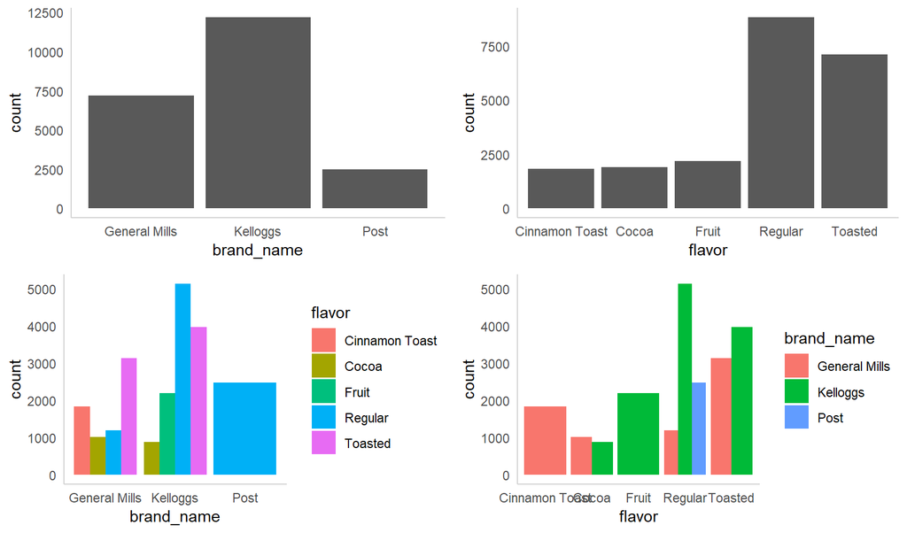

```r
# Code histograms using grid.arrange so can see all quant variables together
# Graph between each promo and its count
# Graph between each flavor and its count
# graph between each brand, its falor and count
# and vice versa
grid.arrange(
  cereal %>%
    ggplot(aes(brand_name)) +
      geom_bar() + theme(axis.text.x = element_text(angle = 45, hjust = 1)) +
       theme_minimal() +
    theme(
      panel.grid.major = element_blank(),
      panel.grid.minor = element_blank(),
    axis.line = element_line(colour = "#D3D3D3")),
  cereal %>%
    ggplot(aes(flavor)) +
      geom_bar() + theme(axis.text.x = element_text(angle = 45, hjust = 1)) +
       theme_minimal() +
    theme(
      panel.grid.major = element_blank(),
      panel.grid.minor = element_blank(),
    axis.line = element_line(colour = "#D3D3D3")),
  cereal %>%
    ggplot(aes(brand_name, fill = flavor)) +
      geom_bar(position = "dodge") + theme(axis.text.x = element_text(angle = 45, hjust = 1)) +
       theme_minimal() +
    theme(
      panel.grid.major = element_blank(),
      panel.grid.minor = element_blank(),
    axis.line = element_line(colour = "#D3D3D3")),
  cereal %>%
    ggplot(aes(x = flavor, fill = brand_name)) +
  geom_bar(position = "dodge") + theme(axis.text.x = element_text(angle = 45, hjust = 1)) +
       theme_minimal() +
    theme(
      panel.grid.major = element_blank(),
      panel.grid.minor = element_blank(),
    axis.line = element_line(colour = "#D3D3D3")),
  ncol = 2
)
```

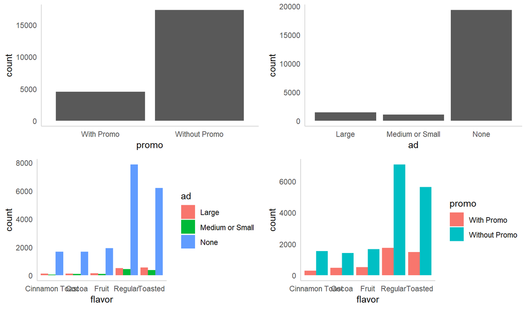

```r
# Graph between each promo and its count
# Graph between each adv and its count
# graph between each promo with adv
# and vice versa
grid.arrange(
  cereal %>%
    ggplot(aes(promo)) +
      geom_bar() +
       theme_minimal() +
    theme(
      panel.grid.major = element_blank(),
      panel.grid.minor = element_blank(),
    axis.line = element_line(colour = "#D3D3D3")),
  cereal %>%
    ggplot(aes(ad)) +
      geom_bar() +
       theme_minimal() +
    theme(
      panel.grid.major = element_blank(),
      panel.grid.minor = element_blank(),
    axis.line = element_line(colour = "#D3D3D3")),
  cereal %>%
    ggplot(aes(flavor, fill = ad)) +
      geom_bar(position = "dodge") + theme(axis.text.x = element_text(angle = 45, hjust = 1)) +
       theme_minimal() +
    theme(
      panel.grid.major = element_blank(),
      panel.grid.minor = element_blank(),
    axis.line = element_line(colour = "#D3D3D3")),
  cereal %>%
    ggplot(aes(flavor, fill = promo)) +
      geom_bar(position = "dodge") + theme(axis.text.x = element_text(angle = 45, hjust = 1)) +
       theme_minimal() +
    theme(
      panel.grid.major = element_blank(),
      panel.grid.minor = element_blank(),
    axis.line = element_line(colour = "#D3D3D3")),
  ncol = 2
)
```

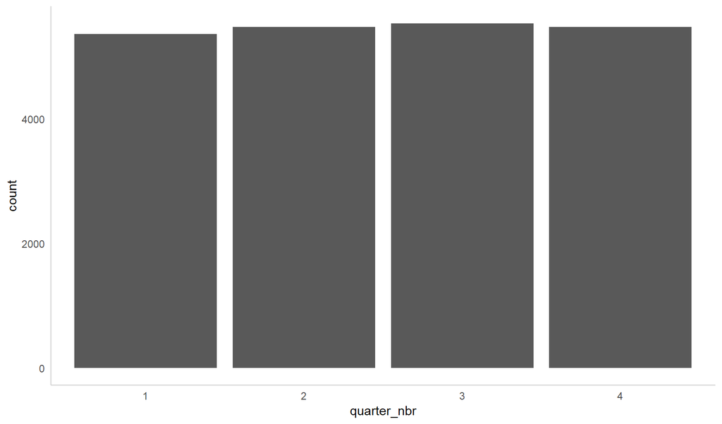

```r
# Graph between no of observations in each quarter
cereal %>%
    ggplot(aes(quarter_nbr)) +
      geom_bar()  + theme(axis.text.x = element_text(hjust = 1)) +
       theme_minimal() +
    theme(
      panel.grid.major = element_blank(),
      panel.grid.minor = element_blank(),
    axis.line = element_line(colour = "#D3D3D3"))
```

**Conclusions:**

- Kelloggs has highest share of the market
- Regular and Toasted are leading flavors
- Post only sells Regular flavored cereals
- Only General Mills sells Cinnamon Toast flavors, while only Kelloggs sells Fruit flavors
- Promos and ads are not run very often
  - Regular and Toasted flavors are mostly promoted through marketing efforts
- Sales seem consistent across all quarters

# 7 **Univariate non-graphical – Quantitative**

```r
# Get descrptive stats
summary(cereal)
```

```
##            upc                brand_name                 product_name
##  014300010521:  676   General Mills: 7189   Frosted Flakes     : 2295
##  013800001621:  666   Kelloggs     :12183   Froot Loops        : 2192
##  013800000828:  660   Post         : 2478   Cinnamon Tst Cr    : 1834
##  011600027569:  639                         Lucky Charms       : 1681
##  023800066330:  618                         Frosted Mini Wheats: 1574
##  013800001611:  612                         Cheerios           : 1458
##  (Other)     :17979                         (Other)            :10816
##             flavor       store_nbr         units            price
##  Cinnamon Toast:1834   656444 :   35   Min.   : 1.000   Min.   :0.250
##  Cocoa         :1901   256951 :   31   1st Qu.: 3.000   1st Qu.:3.190
##  Fruit         :2192   259661 :   31   Median : 7.000   Median :3.790
##  Regular       :8816   267403 :   31   Mean   : 8.579   Mean   :3.763
##  Toasted       :7107   652139 :   31   3rd Qu.:12.000   3rd Qu.:4.390
##                        681735 :   31   Max.   :28.000   Max.   :9.990
##                        (Other):21660
##      sales            volume      package        week_nbr
##  Min.   :  0.48   Min.   :0.040   Box:21306   22     :  475
##  1st Qu.: 11.80   1st Qu.:0.750   Cup:  544   12     :  473
##  Median : 24.50   Median :1.060               37     :  464
##  Mean   : 31.01   Mean   :1.016               29     :  449
##  3rd Qu.: 44.09   3rd Qu.:1.120               20     :  445
##  Max.   :155.48   Max.   :4.000               43     :  445
##                                               (Other):19099
##            promo                     ad        discount_offered
##  With Promo   : 4545   Large          : 1456   No :17305
##  Without Promo:17305   Medium or Small: 1061   Yes: 4545
##                        None           :19333
##
##
##
##
##  promo_plus_ad quarter_nbr
##  Ad   : 1085   1:5364
##  Both : 1432   2:5475
##  None :16220   3:5533
##  Promo: 3113   4:5478
##
##
##
```

**Conclusions:**

# 8 ## Univariate graphical – Quantitative

We need to look at histograms of quantitative variables to confirm what we have just seen.

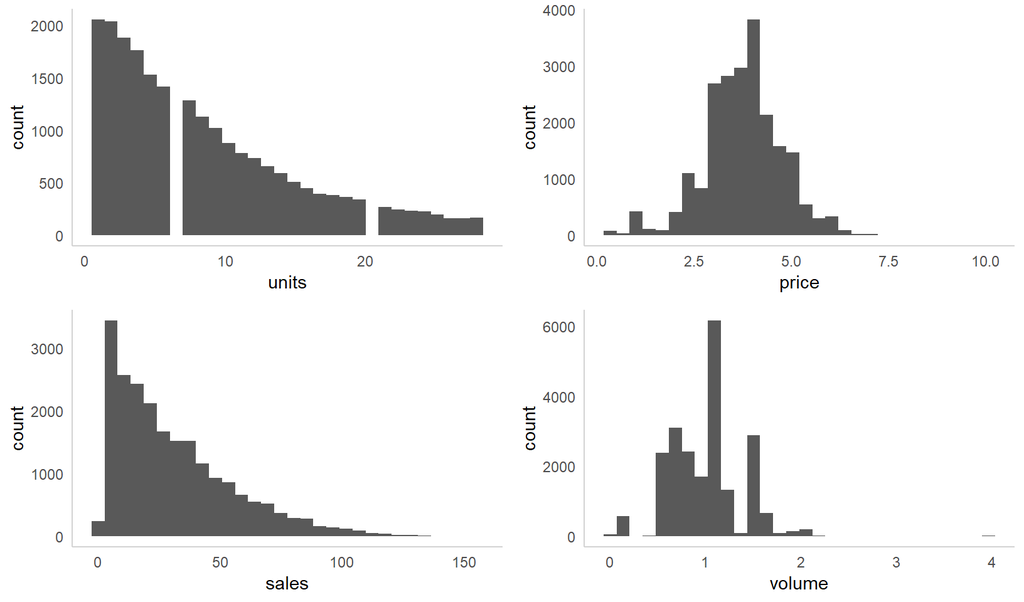

```r
# Code histograms using grid.arrange so can see all quant variables together
# histogram to see how sales, price, unit and volume is distributed in sample given
grid.arrange(
  cereal %>%
    ggplot(aes(units)) +
      geom_histogram() +
       theme_minimal() +
    theme(
      panel.grid.major = element_blank(),
      panel.grid.minor = element_blank(),
    axis.line = element_line(colour = "#D3D3D3")),
  cereal %>%
    ggplot(aes(price)) +
      geom_histogram() +
       theme_minimal() +
    theme(
      panel.grid.major = element_blank(),
      panel.grid.minor = element_blank(),
    axis.line = element_line(colour = "#D3D3D3")),
  cereal %>%
    ggplot(aes(sales)) +
      geom_histogram() +
       theme_minimal() +
    theme(
      panel.grid.major = element_blank(),
      panel.grid.minor = element_blank(),
    axis.line = element_line(colour = "#D3D3D3")),
  cereal %>%
    ggplot(aes(volume)) +
      geom_histogram() +
       theme_minimal() +
    theme(
      panel.grid.major = element_blank(),
      panel.grid.minor = element_blank(),
    axis.line = element_line(colour = "#D3D3D3")),
  ncol = 2
)
```

**Conclusions:**

- Number of Units sold has a skewed distribution
  - It makes sense because normally people don’t buy in large quantities
- Price of the product is almost normally distributed but interesting variable will be price per unit
- Sales distribution is almost similar to units sold
  - It makes sense because they can be highly correlated
- Volume of each package shows that most demand is around unit 1.0
  - But there are still outliers at both extremes

**Boxplots of quantitative data**

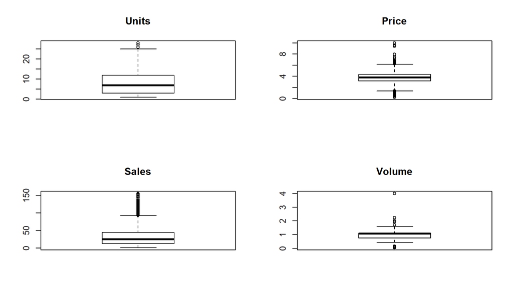

```r
# Set grid pattern for graph arrangement
# draw the box plots to see the variation in all quantitative variables : unit, price,volume, sales
par(mfrow = c(2, 2))
boxplot(cereal$units, main = "Units")
boxplot(cereal$price, main = "Price")
boxplot(cereal$sales, main = "Sales")
boxplot(cereal$volume, main = "Volume")
```

```r
# boxplot(cereal$price_per_unit, main = "Price per Unit")
```

**Conclusions**

- Price has a large number of outliers on both extremes
- Sales also has outliers, on the higher side

# 9 Multivariate non-graphical – Categorical

Use cross-tabs for counts/proportion/percent

```r
# brand name vs flavor table
cereal %>%
  tabyl(brand_name, flavor) %>%
  adorn_totals(where = c("row", "col")) %>%
  kableExtra::kable() %>%
  kable_styling(full_width = FALSE)
```

| brand_name | Cinnamon Toast | Cocoa | Fruit | Regular | Toasted | Total |
| --- | --- | --- | --- | --- | --- | --- |
| General Mills | 1834 | 1020 | 0 | 1203 | 3132 | 7189 |
| Kelloggs | 0 | 881 | 2192 | 5135 | 3975 | 12183 |
| Post | 0 | 0 | 0 | 2478 | 0 | 2478 |
| Total | 1834 | 1901 | 2192 | 8816 | 7107 | 21850 |

```r
# Proportions might be more informative
cereal %>%
  tabyl(brand_name, flavor) %>%
  adorn_totals(where = c("row", "col")) %>%
  adorn_percentages(denominator = "all") %>%
  adorn_pct_formatting(digits = 0) %>%
  kableExtra::kable() %>%
  kable_styling(full_width = FALSE)
```

| brand_name | Cinnamon Toast | Cocoa | Fruit | Regular | Toasted | Total |
| --- | --- | --- | --- | --- | --- | --- |
| General Mills | 8% | 5% | 0% | 6% | 14% | 33% |
| Kelloggs | 0% | 4% | 10% | 24% | 18% | 56% |
| Post | 0% | 0% | 0% | 11% | 0% | 11% |
| Total | 8% | 9% | 10% | 40% | 33% | 100% |

**Conclusions:**

- General Mills
  - They own 33% of market share; with 14% pertaining to sales of Toasted flavors while 8% pertains to Cinnamon Toast flavors
- Kelloggs
  - They own 56% of market share; with 24% pertaining to Regular flavors, 18% of Toasted and 10% in Fruit flavors sold by them
- Post
  - They only make Regular flavor and own 11.3% of the market share

```r
# brand vs quarter number information table
cereal %>%
  tabyl(brand_name, quarter_nbr) %>%
  adorn_totals(where = c("row", "col")) %>%
  kableExtra::kable() %>%
  kable_styling(full_width = FALSE)
```

| brand_name | 1 | 2 | 3 | 4 | Total |
| --- | --- | --- | --- | --- | --- |
| General Mills | 1877 | 1804 | 1707 | 1801 | 7189 |
| Kelloggs | 2852 | 3008 | 3224 | 3099 | 12183 |
| Post | 635 | 663 | 602 | 578 | 2478 |
| Total | 5364 | 5475 | 5533 | 5478 | 21850 |

```r
# Proportions might be more informative
cereal %>%
  tabyl(brand_name, quarter_nbr) %>%
  adorn_totals(where = c("row", "col")) %>%
  adorn_percentages(denominator = "all") %>%
  adorn_pct_formatting(digits = 0) %>%
  kableExtra::kable() %>%
  kable_styling(full_width = FALSE)
```

| brand_name | 1 | 2 | 3 | 4 | Total |
| --- | --- | --- | --- | --- | --- |
| General Mills | 9% | 8% | 8% | 8% | 33% |
| Kelloggs | 13% | 14% | 15% | 14% | 56% |
| Post | 3% | 3% | 3% | 3% | 11% |
| Total | 25% | 25% | 25% | 25% | 100% |

**Conclusions:**

- Although Regular and Toasted are sold more than any other flavor, sales doesn’t vary much by quarter.

# 10 ## Multivariate graphical code – Categorical

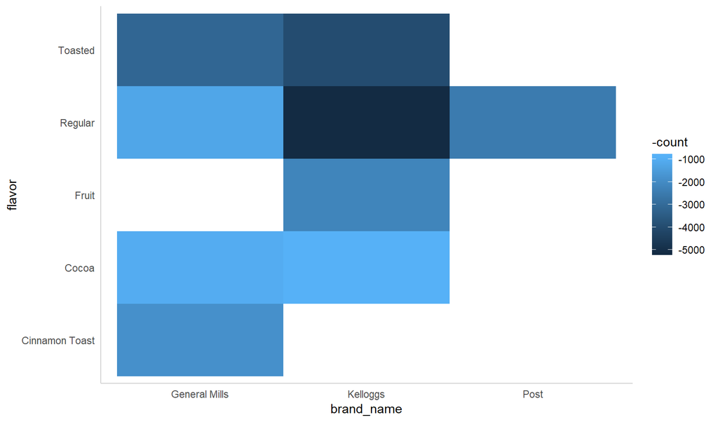

```r
# calculate count and provide a variable for filling the graph
# a heat map to see the number of observation of each flavor in each brand
cereal %>%
  group_by(brand_name, flavor) %>%
  summarise(count = n()) %>%
  ggplot(aes(brand_name, flavor)) +
  geom_tile(aes(fill = -count)) +
       theme_minimal() +
    theme(
      panel.grid.major = element_blank(),
      panel.grid.minor = element_blank(),
    axis.line = element_line(colour = "#D3D3D3"))
```

**Conclusions:**

- Regular flavor
- Sold by each brand
- Kelloggs sells it more than others
- General Mills
- Most sale is aorund Toasted and Cinnamon Flavor
- They are not into Fruit flavor business
- Kelloggs
- They have the highest sale with Regular, Toasted and Fruit flavor
- Post
- They sells only Regular but have high sale than General Mills regular flavor

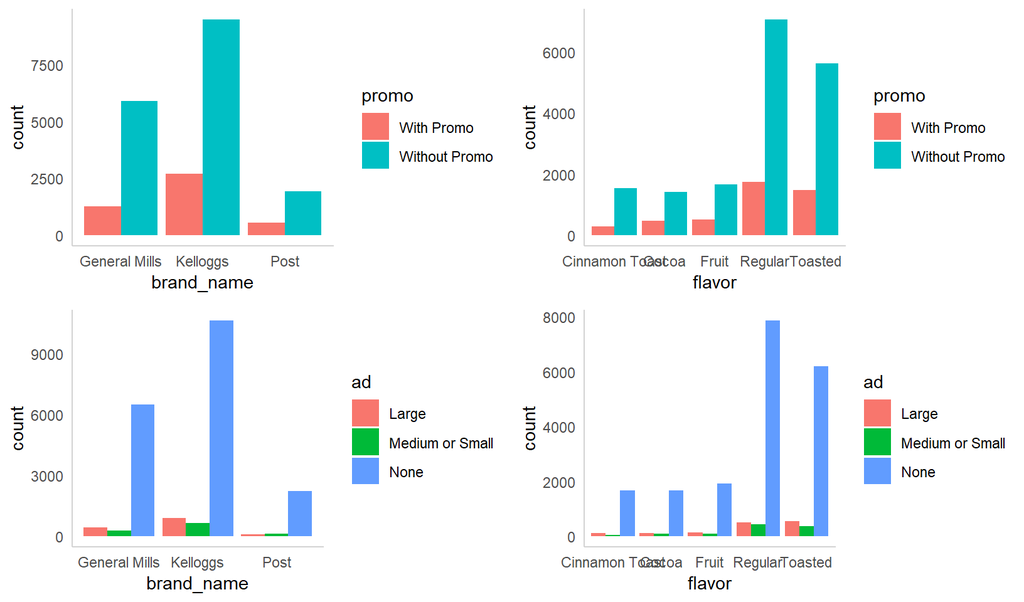

```r
# calculate count and provide a variable for filling the graph
# to see the relationship between brand and promo or ad
# to see the relationship between flavor and promo or ad
grid.arrange(
  cereal %>%
    group_by(brand_name, promo) %>%
    summarise(count = n()) %>%
    ggplot(aes(x = brand_name, count, fill = promo)) +
    geom_bar(stat = "identity", position = "dodge") +
       theme_minimal() +
    theme(
      panel.grid.major = element_blank(),
      panel.grid.minor = element_blank(),
    axis.line = element_line(colour = "#D3D3D3")),
  cereal %>%
    group_by(flavor, promo) %>%
    summarise(count = n()) %>%
    ggplot(aes(x = flavor, count, fill = promo)) +
    geom_bar(stat = "identity", position = "dodge") +
       theme_minimal() +
    theme(
      panel.grid.major = element_blank(),
      panel.grid.minor = element_blank(),
    axis.line = element_line(colour = "#D3D3D3")),
  cereal %>%
    group_by(brand_name, ad) %>%
    summarise(count = n()) %>%
    ggplot(aes(x = brand_name, count, fill = ad)) +
    geom_bar(stat = "identity", position = "dodge") +
       theme_minimal() +
    theme(
      panel.grid.major = element_blank(),
      panel.grid.minor = element_blank(),
    axis.line = element_line(colour = "#D3D3D3")),
  cereal %>%
    group_by(flavor, ad) %>%
    summarise(count = n()) %>%
    ggplot(aes(x = flavor, count, fill = ad)) +
    geom_bar(stat = "identity", position = "dodge") +
       theme_minimal() +
    theme(
      panel.grid.major = element_blank(),
      panel.grid.minor = element_blank(),
    axis.line = element_line(colour = "#D3D3D3")),
  ncol = 2
)
```

**Conclusions:**

- Regular and Toasted flavors are promoted more than others

# 11 ## Multivariate non-graphical – Quantitative

The standard measure we can use to assess relationships is correlation.

```r
# Find correlation of quantiative variables

cor(cereal[, c(6:9)])
```

```
##              units      price     sales     volume
## units   1.00000000 -0.1907078 0.9061386 0.02371249
## price  -0.19070782  1.0000000 0.1527556 0.54332999
## sales   0.90613858  0.1527556 1.0000000 0.20001035
## volume  0.02371249  0.5433300 0.2000103 1.00000000
```

**Conclusion:**

There are varying amounts of correlation between variables. We’ll confirm the same graphically.

# 12 Multivariate graphical code – Quantitative

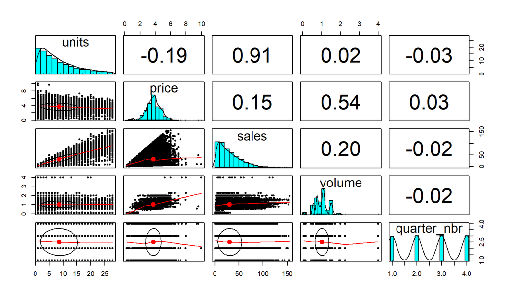

```r
# the correlation plot from the psych package -- `install.package("psych")` if not installed already

pairs.panels(cereal[, c(6:9, 16)])
```

# 13 ## Multivariate non-graphical – Categorical and Quantitative

```r
# tapply function is like other apply functions but does a function [sum in this case] over an indicie [Region in this case]
# apply functions are generally
# Mean price of each brand

brand_flavor <- round(rbind(
  tapply(cereal[cereal$brand_name == "General Mills",]$price, cereal[cereal$brand_name == "General Mills",]$flavor, mean),
  tapply(cereal[cereal$brand_name == "Kelloggs",]$price, cereal[cereal$brand_name == "Kelloggs",]$flavor, mean),
  tapply(cereal[cereal$brand_name == "Post",]$price, cereal[cereal$brand_name == "Post",]$flavor, mean)
  ),
  0)
row.names(brand_flavor) <- c("General Mills", "Kelloggs", "Post")

brand_flavor %>%
  kableExtra::kable() %>%
  kable_styling(full_width = FALSE)
```

|  | Cinnamon Toast | Cocoa | Fruit | Regular | Toasted |
| --- | --- | --- | --- | --- | --- |
| General Mills | 4 | 3 | NA | 4 | 4 |
| Kelloggs | NA | 4 | 4 | 4 | 4 |
| Post | NA | NA | NA | 4 | NA |

```r
# total of sales per brand

brand_flavor_sale <- round(rbind(
  tapply(cereal[cereal$brand_name == "General Mills",]$sales, cereal[cereal$brand_name == "General Mills",]$flavor, sum),
  tapply(cereal[cereal$brand_name == "Kelloggs",]$sales, cereal[cereal$brand_name == "Kelloggs",]$flavor, sum),
  tapply(cereal[cereal$brand_name == "Post",]$sales, cereal[cereal$brand_name == "Post",]$flavor, sum)
  ),
  0)
row.names(brand_flavor_sale) <- c("General Mills", "Kelloggs", "Post")

brand_flavor_sale %>%
  kableExtra::kable() %>%
  kable_styling(full_width = FALSE)
```

|  | Cinnamon Toast | Cocoa | Fruit | Regular | Toasted |
| --- | --- | --- | --- | --- | --- |
| General Mills | 62638 | 26257 | NA | 32459 | 135335 |
| Kelloggs | NA | 14950 | 45200 | 178723 | 125706 |
| Post | NA | NA | NA | 56349 | NA |

# 14 Exploratory Data Analysis (Detailed)

## 14.1 How does each producer compare?

```r
# sales and units by producer

by_producer <- cereal %>%
  group_by(brand_name) %>%
  summarise(total_revenue = sum(sales), total_units = sum(units))

by_producer %>%
  mutate(total_revenue = dollar(total_revenue),
         total_units = comma(total_units)) %>%
  rename(`Brand Name` = brand_name,
         `Total Revenue` = total_revenue,
         `Total Units` = total_units) %>%
  kableExtra::kable(col.names = c("Producer", "Total Revenue", "Total Units")) %>%
  kable_styling(full_width = FALSE) %>%
  footnote(general = "Table above shows total revenue and units for the entire year")
```

| Producer | Total Revenue | Total Units |
| --- | --- | --- |
| General Mills | $256,689 | 69,017 |
| Kelloggs | $364,579 | 102,512 |
| Post | $56,349 | 15,921 |

Note:  
Table above shows total revenue and units for the entire year

**Conclusions**: We see that Kelloggs is the market leader.

## 14.2 How consistent is each producer’s performance?

We answer this question by looking at revenue by quarter.

```r
# sales and units by producer by quarter

by_producer_by_qtr <- cereal %>%
  group_by(brand_name, quarter_nbr) %>%
  summarise(total_revenue = sum(sales), total_units = sum(units))

by_producer_by_qtr %>%
  mutate(total_revenue = dollar(total_revenue),
         total_units = comma(total_units)) %>%
  # ungroup() %>%
  gather(variable, value, -(brand_name:quarter_nbr)) %>%
  unite(temp, brand_name, variable) %>%
  spread(temp, value) %>%
  kableExtra::kable(col.names = c("Quarter", rep(c("Sales", "Units"), times = 3))) %>%
  kable_styling(full_width = FALSE) %>%
  add_header_above(c(" " = 1, "General Mills" = 2, "Kelloggs" = 2, "Post" = 2)) %>%
  footnote(general = "Table above shows total revenue and units by quarter for the entire year")
```

| Quarter | General Mills Sales | General Mills Units | Kelloggs Sales | Kelloggs Units | Post Sales | Post Units |
| --- | --- | --- | --- | --- | --- | --- |
| 1 | $66,601.52 | 18,250 | $88,944.54 | 25,329 | $15,503.67 | 4,463 |
| 2 | $64,892.64 | 17,412 | $90,542.87 | 25,478 | $15,048.81 | 4,260 |
| 3 | $61,419.09 | 16,384 | $92,317.31 | 26,003 | $13,758.53 | 3,867 |
| 4 | $63,776.23 | 16,971 | $92,773.79 | 25,702 | $12,037.63 | 3,331 |

Note:  
Table above shows total revenue and units by quarter for the entire year

**Conclusions**:

- General Mills performance declined over the year, but improved in Quarter 4
- Unlike our main competition, change in units was accompanied by similar change in revenue

## 14.3 What is the top performing cereal in the market?

It would be appropriate to evaluate product popularity based on total revenue.

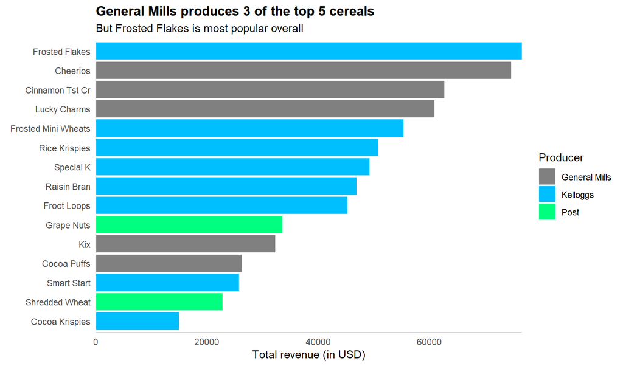

```r
# check who produces the most popular cereals in terms of revenue and units

most_popular_cereal <- cereal %>%
  group_by(brand_name, product_name) %>%
  summarise(total_revenue = sum(sales), total_units = sum(units)) %>%
  arrange(desc(total_revenue))

# bar plot shows revenue by producer

ggplot(data = most_popular_cereal,
       aes(x = reorder(product_name, total_revenue), y = total_revenue,
           fill = brand_name)) +
  geom_bar(stat = "identity") +
  theme_minimal() +
  scale_x_discrete(name = element_blank()) +
  scale_y_continuous(name = "Total revenue (in USD)",
                     limits = c(0, max(most_popular_cereal$total_revenue)),
                     expand = c(0, 0)) +
  scale_fill_manual(
    name = "Producer",
    values = c(colour_grey_5, colour_blue_2, colour_green_1)
  ) +
  theme(
    plot.title = element_text(colour = "black", face = "bold", size = 13),
    panel.grid.major = element_blank(),
    panel.grid.minor = element_blank(),
    axis.line = element_line(colour = colour_grey_3)
  ) +
  ggtitle(label = "General Mills produces 3 of the top 5 cereals",
          subtitle = "But Frosted Flakes is most popular overall") +
  coord_flip()
```

**Conclusions**:

- Cheerios is the most popular of our products; does not lag very far behind Frosted Flakes
- Cinnamon Toast Crunch and Lucky Charms are also in the top 5

### 14.3.1 Does cereal popularity differ during the year? (Rank by quarter)

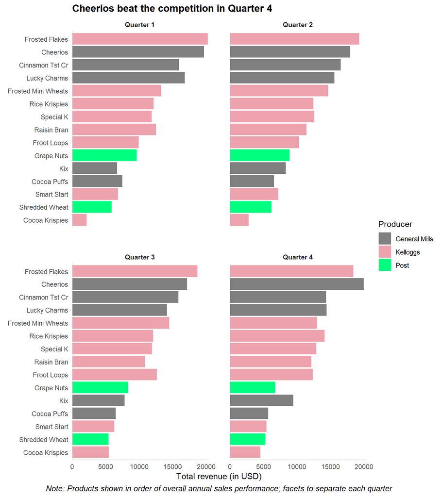

```r
# check who produces the most popular cereals by quarter in terms of revenue and units

most_popular_cereal_qtr <- cereal %>%
  group_by(brand_name, product_name, quarter_nbr) %>%
  summarise(total_revenue = sum(sales), total_units = sum(units)) %>%
  ungroup() %>%
  group_by(quarter_nbr) %>%
  mutate(quarter_rank = dense_rank(desc(total_revenue)))

# Bar graph (horizontal) faceted by quarter, coloured by brand

levels(most_popular_cereal_qtr$quarter_nbr)[
  levels(most_popular_cereal_qtr$quarter_nbr) == "1"
] <- "Quarter 1"
levels(most_popular_cereal_qtr$quarter_nbr)[
  levels(most_popular_cereal_qtr$quarter_nbr) == "2"
] <- "Quarter 2"
levels(most_popular_cereal_qtr$quarter_nbr)[
  levels(most_popular_cereal_qtr$quarter_nbr) == "3"
] <- "Quarter 3"
levels(most_popular_cereal_qtr$quarter_nbr)[
  levels(most_popular_cereal_qtr$quarter_nbr) == "4"
] <- "Quarter 4"

ggplot(data = most_popular_cereal_qtr,
       aes(x = reorder(product_name, total_revenue), y = total_revenue,
           fill = brand_name)) +
  geom_bar(stat = "identity") +
  facet_wrap(
    quarter_nbr ~ ., nrow = 2, ncol = 2
  ) +
  theme_minimal() +
  scale_x_discrete(name = element_blank()) +
  scale_y_continuous(name = "Total revenue (in USD)",
                     limits = c(0, max(most_popular_cereal_qtr$total_revenue)),
                     expand = c(0, 0)) +
  scale_fill_manual(
    name = "Producer",
    values = c(colour_grey_5, colour_red_1, colour_green_1)
  ) +
  theme(
    plot.title = element_text(colour = "black", face = "bold", size = 13),
    plot.caption = element_text(face = "italic", size = 10, hjust = 0.5),
    panel.spacing = unit(2, "lines"),
    strip.text.x = element_text(face = "bold"),
    panel.grid.major = element_blank(),
    panel.grid.minor = element_blank(),
    axis.line = element_line(colour = colour_grey_3)
  ) +
  ggtitle(label = "Cheerios beat the competition in Quarter 4") +
  labs(caption = "Note: Products shown in order of overall annual sales performance; facets to separate each quarter") +
  coord_flip()
```

**Conclusions**:

- Cheerios ranked highest in terms of revenue in Q4
- Need to investigate Q4 performance to understand reasons behind improvement
- All other products were mostly consistent in ranking

### 14.3.2 Does cereal popularity differ across stores?

Following is the method used:

- Products are ranked by store
- The ranked products are placed into 3 tiers:
  - The top 33% of ranks are placed into the **“Top Third”**
  - The middle 33% of ranks are placed into the **“Middle Third”**
  - The bottom 33% of ranks are placed into the **“Bottom Third”**
- Note: Not every product sells in every store, per the sample. Hence the division into three tiers accordingly.
  - If 12 cereals sell in a store, Ranks 1-4, 5-8, 9-12 are placed into the tiers respectively.

Interpretation of graph below: For every product, in how many stores is it present in the “Top Third”, “Middle Third” and “Bottom Third”.

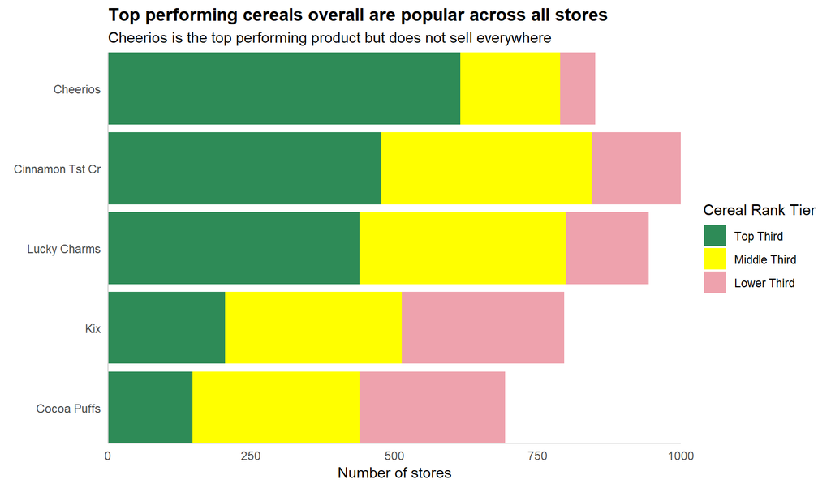

```r
# mapping of brands, products and flavors

brand_product_mapping <- cereal %>%
  select(brand_name, product_name, flavor) %>%
  filter(!(product_name == "Lucky Charms" & flavor == "Regular" |
             product_name == "Cheerios" & flavor == "Regular")) %>%
  unique()

# ranking cereal into tiers by week, quarter and overall

cereal_rank_tiers <- cereal %>%
  group_by(store_nbr, product_name) %>%
  summarise(total_revenue = sum(sales)) %>%
  mutate(cereal_rank = dense_rank(desc(total_revenue))) %>%
  ungroup() %>%
  group_by(store_nbr) %>%
  mutate(cereal_rank_bin = case_when(
    cereal_rank <= 1 * ceiling(n() / 3) ~ "Top Third",
    cereal_rank <= 2 * ceiling(n() / 3) ~ "Middle Third",
    cereal_rank <= 3 * ceiling(n() / 3) ~ "Lower Third"
  )) %>%
  select(-total_revenue) %>%
  group_by(product_name, cereal_rank_bin) %>%
  summarise(no_of_stores = n()) %>%
  inner_join(brand_product_mapping) %>%
  select(brand_name, flavor, everything())

most_popular_cereal_gm <- most_popular_cereal %>%
  ungroup() %>% filter(brand_name == "General Mills") %>% as.data.frame()
gen_mills_ranked <- as.character(most_popular_cereal_gm$product_name)
ranking_tiers <- c("Top Third", "Middle Third", "Lower Third")

# Bar chart showing popularity by product, color fade, **GM only**

ggplot(data = cereal_rank_tiers %>%
         filter(brand_name == "General Mills"),
       aes(x = factor(product_name, levels = rev(gen_mills_ranked)),
           y = no_of_stores,
           fill = cereal_rank_bin
             # factor(cereal_rank_bin, levels = rev(ranking_tiers))
           )
  ) +
  geom_bar(stat = "identity") +
  scale_x_discrete(
    name = element_blank(), expand = c(0, 0)
  ) +
  scale_y_continuous(
    name = "Number of stores", expand = c(0, 0)
  ) +
  scale_fill_manual(name = "Cereal Rank Tier",
                    values = c(colour_red_1, colour_yellow_1, colour_green_2)) +
  guides(fill = guide_legend(reverse = TRUE)) +
  theme_minimal() +
  theme(
    plot.title = element_text(colour = "black", face = "bold", size = 13),
    panel.grid.major = element_blank(),
    panel.grid.minor = element_blank(),
    axis.line = element_line(colour = colour_grey_3)
  ) +
  ggtitle(
    label = "Top performing cereals overall are popular across all stores",
    subtitle = "Cheerios is the top performing product but does not sell everywhere"
  ) +
  coord_flip()
```

**Conclusions**:

- Cheerios is our top performing product but sells in only 850 stores.
  - That seems unexpected
- Top performers are generally in the Top Third in more stores than others.
  - This is expected, but it’s good to have confirmation.

### 14.3.3 How does this compare against our competition?

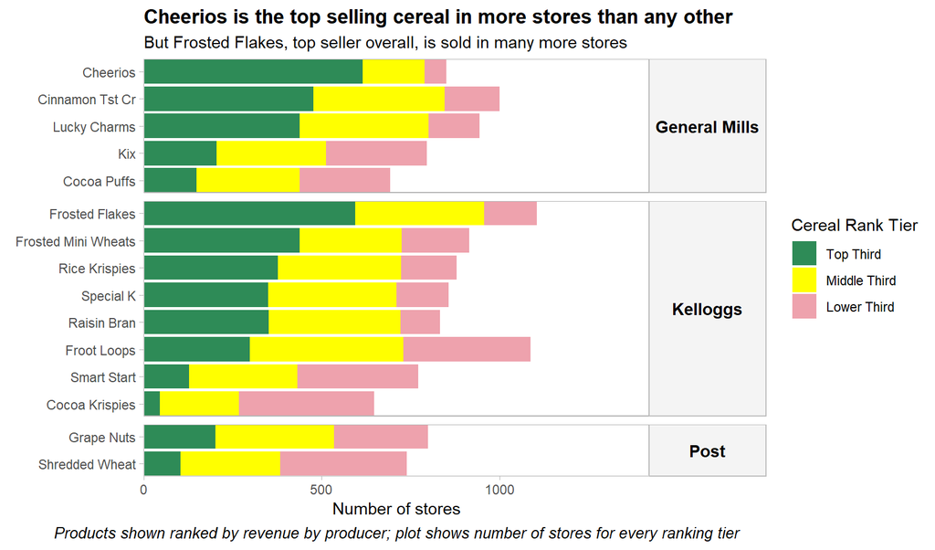

```r
# get a vector of top performing cereal

top_cereal_figures <- most_popular_cereal %>% ungroup() %>% as.data.frame()
top_cereal_list <- as.character(top_cereal_figures$product_name)

# bar chart similar to previous, but including all products, faceted by brand, coloured by ranking tier

ggplot(data = cereal_rank_tiers,
       aes(x = factor(product_name, levels = rev(top_cereal_list)),
           y = no_of_stores,
           fill = cereal_rank_bin)
  ) +
  geom_bar(stat = "identity") +
  scale_x_discrete(
    name = element_blank(), expand = c(0, 0)
  ) +
  scale_y_continuous(
    name = "Number of stores",
    limits = c(0, length(unique(cereal$store_nbr))),
    expand = c(0, 0)
  ) +
  scale_fill_manual(name = "Cereal Rank Tier",
                    values = c(colour_red_1, colour_yellow_1, colour_green_2)) +
  guides(fill = guide_legend(reverse = TRUE)) +
  facet_grid(brand_name ~ .,
    space = "free_y", scales = "free_y"
  ) +
  theme_light() +
  theme(
    plot.title = element_text(colour = "black", face = "bold", size = 13),
    plot.caption = element_text(face = "italic", size = 10, hjust = 0.5),
    panel.grid.major = element_blank(),
    panel.grid.minor = element_blank(),
    axis.line = element_line(colour = colour_grey_3),
    strip.background = element_rect(fill = colour_grey_1, colour = "grey"),
    strip.text.y = element_text(
      colour = "black", size = 11, face = "bold",
      angle = 360
    )
  ) +
  ggtitle(
    label = "Cheerios is the top selling cereal in more stores than any other",
    subtitle = "But Frosted Flakes, top seller overall, is sold in many more stores"
  ) +
  labs(
    caption = "Products shown ranked by revenue by producer; plot shows number of stores for every ranking tier"
  ) +
  coord_flip()
```

**Conclusions**:

- Frosted Flakes is most widely sold overall
  - It sells in nearly 250 more stores than Cheerios overall
- Nearly 7 other types of cereal sell in more number of stores than Cheerios
- But Cheerios is in the “Top Third” in more stores than any other product.

### 14.3.4 How have General Mills products performed during the year?

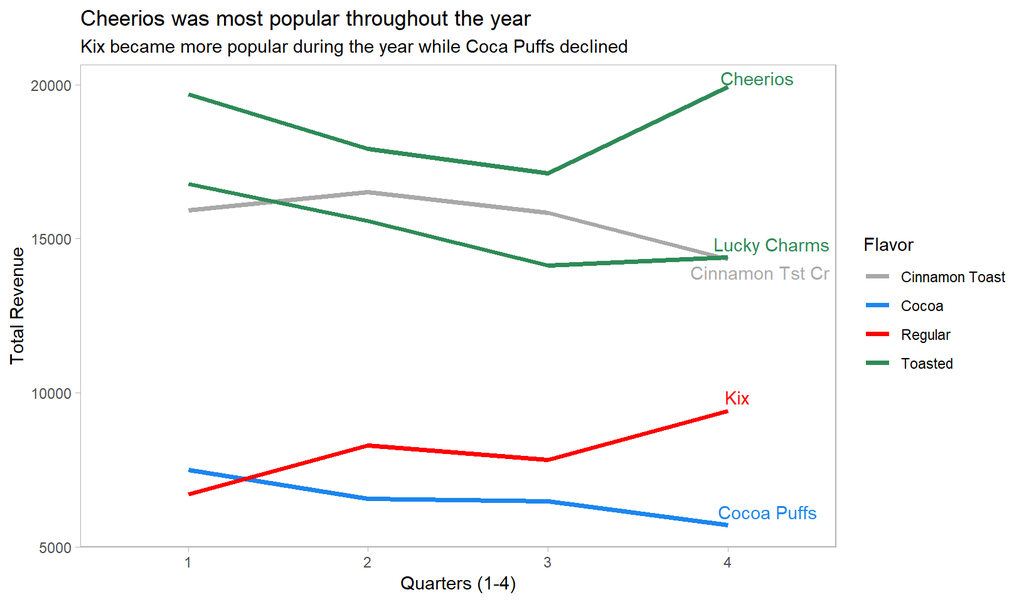

```r
# ranking cereals by quarter

cereal_rank_by_qtr <- cereal %>%
  group_by(brand_name, product_name, quarter_nbr) %>%
  summarise(total_revenue = sum(sales)) %>%
  ungroup() %>%
  group_by(quarter_nbr) %>%
  mutate(cereal_rank_qtr = dense_rank(desc(total_revenue))) %>%
  arrange(quarter_nbr, cereal_rank_qtr)

# subsetting cereal_rank_by_qtr to include only General Mills

data_plot_qtr_subset <- cereal_rank_by_qtr %>%
  inner_join(brand_product_mapping) %>%
  filter(brand_name == "General Mills")

# Line chart showing cereal performance by quarter

ggplot(
    data = data_plot_qtr_subset,
    aes(x = quarter_nbr, y = total_revenue,
        colour = flavor, group = product_name, label = product_name)
  ) +
  geom_line(size = 1.25) +
  geom_text_repel(data = data_plot_qtr_subset %>% filter(quarter_nbr == 4),
      nudge_y = if_else(data_plot_qtr_subset$product_name == "Cinnamon Tst Cr", -100, 0),
      force = 0.5, direction = "y",
      hjust = 0.1, segment.colour = "transparent", show.legend = FALSE) +
  theme_light() +
  theme(
    panel.grid.major = element_blank(),
    panel.grid.minor = element_blank()
  ) +
  scale_x_discrete(name = "Quarters (1-4)") +
  scale_y_continuous(name = "Total Revenue") +
  scale_color_manual(name = "Flavor",
    values = c(colour_grey_4, colour_blue_3, colour_red_2, colour_green_2)
  ) +
  ggtitle(
    label = "Cheerios was most popular throughout the year",
    subtitle = "Kix became more popular during the year while Coca Puffs declined"
  )
```

**Conclusions**:

- We see that Cheerios beating competition in Quarter 4 was a result of improved performance.
  - This was after declines in Q2 and Q3.
- Most other products seemed to decline during the year but Quarter 4.

## 14.4 What product choices do customers have?

### 14.4.1 Does each product sell in one flavor only?

Also: Which products have competition? (competitor products - same flavor, diff brand)

```r
# sum of sales by cereal by flavor
# this is to check how much producers earn by flavor
# this is also to check as to which products sell in multiple flavors

cereal_by_flavor <- cereal %>%
  group_by(brand_name, product_name, flavor) %>%
  summarise(total_revenue = sum(sales))

# Table showing sales in each flavor

cereal_by_flavor %>%
  arrange(desc(total_revenue)) %>%
  ungroup() %>%
  mutate(total_revenue = dollar(total_revenue)) %>%
  spread(flavor, total_revenue) %>%
  replace(is.na(.), '') %>%
  select(-brand_name) %>%
  rename("Product Name" = product_name) %>%
  kableExtra::kable() %>%
  kable_styling(full_width = FALSE) %>%
  row_spec(c(1, 5), background = colour_grey_2) %>%
  group_rows("General Mills", 1, 5) %>%
  group_rows("Kelloggs", 6, 13) %>%
  group_rows("Post", 14, 15) %>%
  footnote(general = "Table above shows total revenue by product by flavor for the entire year")
```

| Product Name | Cinnamon Toast | Cocoa | Fruit | Regular | Toasted |
| --- | --- | --- | --- | --- | --- |
| **General Mills** |  |  |  |  |  |
| Cheerios |  |  |  | $133.14 | $74,503.95 |
| Cinnamon Tst Cr | $62,638.35 |  |  |  |  |
| Cocoa Puffs |  | $26,257.28 |  |  |  |
| Kix |  |  |  | $32,273.14 |  |
| Lucky Charms |  |  |  | $52.81 | $60,830.81 |
| **Kelloggs** |  |  |  |  |  |
| Cocoa Krispies |  | $14,949.59 |  |  |  |
| Froot Loops |  |  | $45,199.73 |  |  |
| Frosted Flakes |  |  |  | $76,550.42 |  |
| Frosted Mini Wheats |  |  |  | $55,314.01 |  |
| Raisin Bran |  |  |  | $46,858.95 |  |
| Rice Krispies |  |  |  |  | $50,753.63 |
| Smart Start |  |  |  |  | $25,753.88 |
| Special K |  |  |  |  | $49,198.30 |
| **Post** |  |  |  |  |  |
| Grape Nuts |  |  |  | $33,564.02 |  |
| Shredded Wheat |  |  |  | $22,784.62 |  |

Note:  
Table above shows total revenue by product by flavor for the entire year

**Conclusions**:

- Cheerios and Lucky Charms (highlighted in grey above) are the only ones selling in multiple flavors
- Revenue from Regular flavors in them is not material

### 14.4.2 Does each product sell in one package only?

**Table showing revenue by package type**

```r
# sum of sales by cereal by package type (Box v/s Cup)

cereal %>%
  group_by(brand_name, product_name, package) %>%
  summarise(total_revenue = sum(sales)) %>%
  mutate(total_revenue = dollar(total_revenue)) %>%
  ungroup() %>%
  spread(package, total_revenue) %>%
  replace(is.na(.), 0) %>%
  select(-brand_name) %>%
  arrange(desc(Box)) %>%
  rename("Product Name" = product_name) %>%
  kableExtra::kable() %>%
  kable_styling(full_width = FALSE) %>%
  row_spec(c(2:4, 11:12), background = colour_grey_1) %>%
  footnote(general = "Table above shows total revenue by product by packaging for the entire year")
```

| Product Name | Box | Cup |
| --- | --- | --- |
| Frosted Flakes | $75,336.80 | $1,213.62 |
| Cheerios | $74,303.90 | $333.19 |
| Cinnamon Tst Cr | $62,064.78 | $573.57 |
| Lucky Charms | $60,352.12 | $531.50 |
| Frosted Mini Wheats | $55,078.22 | $235.79 |
| Rice Krispies | $50,591.93 | $161.70 |
| Special K | $48,411.48 | $786.82 |
| Raisin Bran | $46,858.95 | 0 |
| Froot Loops | $44,353.62 | $846.11 |
| Grape Nuts | $33,564.02 | 0 |
| Kix | $32,273.14 | 0 |
| Cocoa Puffs | $26,257.28 | 0 |
| Smart Start | $25,753.88 | 0 |
| Shredded Wheat | $22,784.62 | 0 |
| Cocoa Krispies | $14,898.20 | $51.39 |

Note:  
Table above shows total revenue by product by packaging for the entire year

**Conclusions**:

- Majority of sales comes from Box
- This is as expected as most cereal customers may be purchasing for households with young children

## 14.5 How do product prices differ by packaging or volume?

Also: How do product prices compare to competitor products with similar flavor?

**Box** volumes and prices are, in general, greater than *Cup*. Hence, we need to compare pricing levels by packaging separately.

(Note: We are only comparing prices against Kelloggs products as they are primary competition.)

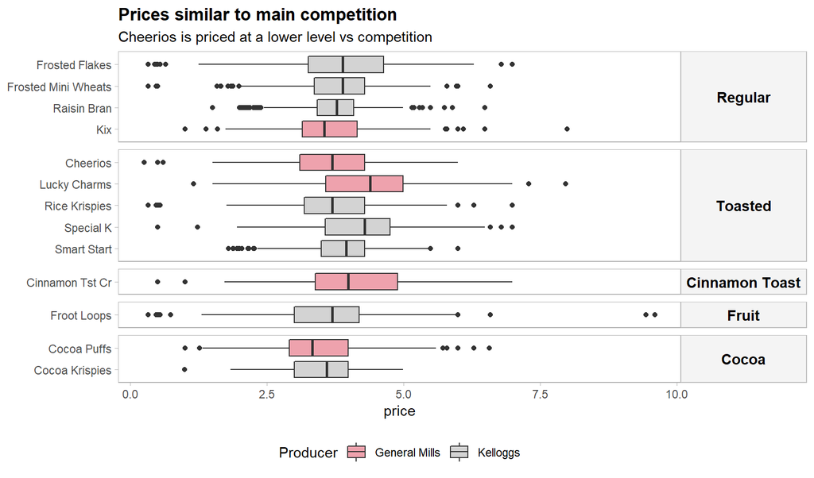

```r
# Boxplot showing price range
# does not include Lucky Charms and Cheerios in Regular flavors are sales are non material

cereal_price_comp <- cereal %>%
  filter(!(product_name == "Lucky Charms" & flavor == "Regular" |
             product_name == "Cheerios" & flavor == "Regular"))

# boxplot showing price ranges

price_boxplot <- function(packaging = "Box") {
  ggplot(
    data = cereal_price_comp %>% filter(brand_name != "Post", package == packaging),
    aes(x = reorder(product_name, sales, sum),
        y = price,
        fill = brand_name)
  ) +
    geom_boxplot() +
    facet_grid(
      factor(flavor,
             levels = c("Regular", "Toasted", "Cinnamon Toast", "Fruit", "Cocoa")
      ) ~ .,
      space = "free_y", scales = "free_y"
    ) +
    scale_fill_manual(
      name = "Producer",
      values = c(colour_red_1, colour_grey_3)
    ) +
    theme_light() +
    theme(
      plot.title = element_text(colour = "black", face = "bold", size = 13),
      panel.grid.major = element_blank(),
      panel.grid.minor = element_blank(),
      axis.title.y = element_blank(),
      legend.position = "bottom",
      strip.background = element_rect(fill = colour_grey_1, colour = "grey"),
      strip.text.y = element_text(
        colour = "black", size = 11, face = "bold",
        angle = 360
      )
    ) +
    coord_flip() +
    ggtitle(
      label = "Prices similar to main competition",
      subtitle = "Cheerios is priced at a lower level vs competition"
    )
}

price_boxplot(packaging = "Box")
```

**Conclusions**:

- Our prices are similar to competition
- Cheerios is priced on the lower side
  - This may mean we don’t have as much room for discouting
- Outliers on either side is indication of wide choice available
- Very low prices may indicate large discounts too; need to investigate further

A summary of price information may confirm what we have seen above.

```r
panderOptions('table.split.table', Inf)

packaging_focus <- "Box"
get_skim_prices <- function(packaging_focus) {
  cereal %>%
    filter(!(product_name == "Lucky Charms" & flavor == "Regular" |
               product_name == "Cheerios" & flavor == "Regular"),
           package == packaging_focus) %>%
    group_by(flavor, product_name) %>%
    skim(price) %>%
  pander()
}

# function used to skim (summary) data separately by Box v/s Cup

get_skim_prices("Box")
```

Skim summary statistics  
n obs: 21299  
n variables: 16

| flavor | product_name | variable | missing | complete | n | mean | sd | p0 | p25 | p50 | p75 | p100 |
| --- | --- | --- | --- | --- | --- | --- | --- | --- | --- | --- | --- | --- |
| Cinnamon Toast | Cinnamon Tst Cr | price | 0 | 1774 | 1774 | 4.14 | 1.05 | 0.5 | 3.38 | 3.99 | 4.89 | 6.99 |
| Cocoa | Cocoa Krispies | price | 0 | 877 | 877 | 3.53 | 0.66 | 0.99 | 3 | 3.59 | 3.99 | 4.99 |
| Cocoa | Cocoa Puffs | price | 0 | 1020 | 1020 | 3.48 | 0.88 | 1 | 2.91 | 3.33 | 3.99 | 6.57 |
| Fruit | Froot Loops | price | 0 | 2099 | 2099 | 3.66 | 0.92 | 0.33 | 3 | 3.69 | 4.19 | 9.6 |
| Regular | Frosted Flakes | price | 0 | 2158 | 2158 | 3.92 | 0.99 | 0.33 | 3.26 | 3.89 | 4.63 | 6.99 |
| Regular | Frosted Mini Wheats | price | 0 | 1539 | 1539 | 3.81 | 0.78 | 0.33 | 3.37 | 3.89 | 4.29 | 6.59 |
| Regular | Grape Nuts | price | 0 | 1289 | 1289 | 3.82 | 0.82 | 1.33 | 3.4 | 3.79 | 4.29 | 9.99 |
| Regular | Kix | price | 0 | 1196 | 1196 | 3.67 | 0.89 | 1 | 3.15 | 3.55 | 4.15 | 7.99 |
| Regular | Raisin Bran | price | 0 | 1266 | 1266 | 3.77 | 0.64 | 1.5 | 3.42 | 3.78 | 4.09 | 6.49 |
| Regular | Shredded Wheat | price | 0 | 1189 | 1189 | 3.52 | 0.67 | 1.29 | 3.05 | 3.59 | 3.98 | 5.89 |
| Toasted | Cheerios | price | 0 | 1407 | 1407 | 3.72 | 0.82 | 0.25 | 3.1 | 3.69 | 4.29 | 5.99 |
| Toasted | Lucky Charms | price | 0 | 1621 | 1621 | 4.34 | 1.09 | 1.16 | 3.58 | 4.39 | 4.99 | 7.96 |
| Toasted | Rice Krispies | price | 0 | 1425 | 1425 | 3.72 | 0.92 | 0.33 | 3.18 | 3.69 | 4.29 | 6.99 |
| Toasted | Smart Start | price | 0 | 1134 | 1134 | 3.83 | 0.71 | 1.8 | 3.49 | 3.95 | 4.29 | 5.99 |
| Toasted | Special K | price | 0 | 1305 | 1305 | 4.19 | 0.85 | 0.5 | 3.57 | 4.29 | 4.75 | 6.99 |

The same holds true for cereals sold in a **Cup**. Only difference is prices are at a much lower level

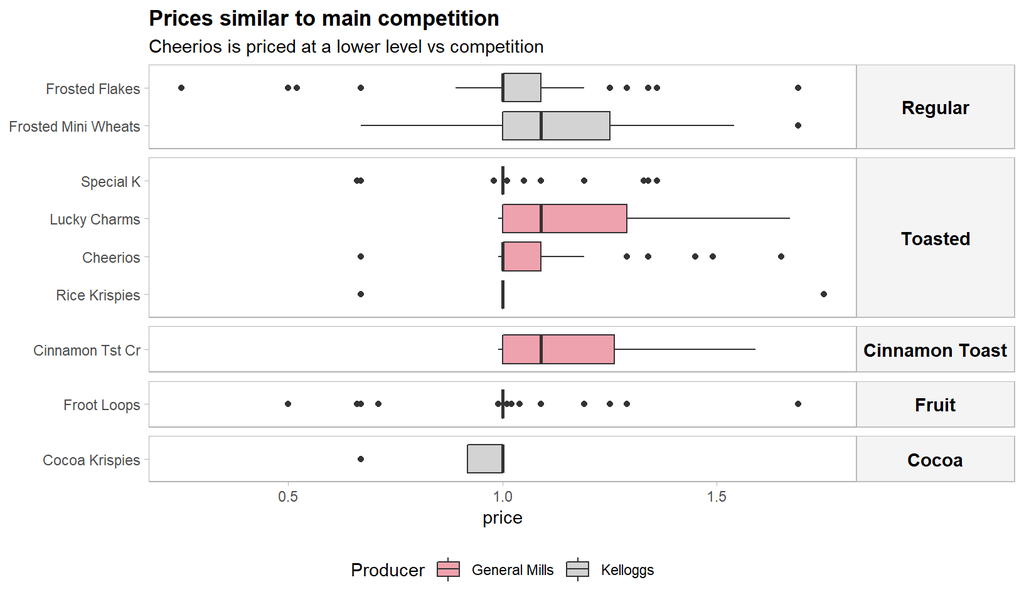

```r
# function used to recreate previous pricing boxplot with Cup

price_boxplot(packaging = "Cup") # to show price ranges for cups are much lower
```

Let’s confirm by looking at price summary for Cups too.

```r
# function used to skim (summary) data separately by Box v/s Cup

get_skim_prices("Cup")
```

Skim summary statistics  
n obs: 544  
n variables: 16

| flavor | product_name | variable | missing | complete | n | mean | sd | p0 | p25 | p50 | p75 | p100 |
| --- | --- | --- | --- | --- | --- | --- | --- | --- | --- | --- | --- | --- |
| Cinnamon Toast | Cinnamon Tst Cr | price | 0 | 60 | 60 | 1.17 | 0.2 | 0.99 | 1 | 1.09 | 1.26 | 1.59 |
| Cocoa | Cocoa Krispies | price | 0 | 4 | 4 | 0.92 | 0.16 | 0.67 | 0.92 | 1 | 1 | 1 |
| Fruit | Froot Loops | price | 0 | 93 | 93 | 1.03 | 0.18 | 0.5 | 1 | 1 | 1 | 1.69 |
| Regular | Frosted Flakes | price | 0 | 137 | 137 | 1.04 | 0.2 | 0.25 | 1 | 1 | 1.09 | 1.69 |
| Regular | Frosted Mini Wheats | price | 0 | 35 | 35 | 1.09 | 0.23 | 0.67 | 1 | 1.09 | 1.25 | 1.69 |
| Toasted | Cheerios | price | 0 | 47 | 47 | 1.08 | 0.17 | 0.67 | 1 | 1 | 1.09 | 1.65 |
| Toasted | Lucky Charms | price | 0 | 57 | 57 | 1.16 | 0.18 | 0.99 | 1 | 1.09 | 1.29 | 1.67 |
| Toasted | Rice Krispies | price | 0 | 25 | 25 | 1 | 0.18 | 0.67 | 1 | 1 | 1 | 1.75 |
| Toasted | Special K | price | 0 | 86 | 86 | 1.03 | 0.12 | 0.66 | 1 | 1 | 1 | 1.36 |

## 14.6 Are promos effective?

### 14.6.1 How do stores that run promos fare in general?

[figure not shown]

```r
brand_focus <- "General Mills"

# sales and units by product, separated by promo v/s no promo

prod_rev_promo <- cereal %>%
  filter(brand_name == brand_focus) %>%
  group_by(product_name, store_nbr, promo) %>%
  summarise(avg_revenue = mean(sales), avg_units = mean(units))

# sales and units by product
# separated by stores that ran promos v/s those that never ran promos during the year

promo_store_with_out_comp <- prod_rev_promo %>%
  mutate(store_both_with_out = if_else(
    sum(promo == "With Promo") + sum(promo == "Without Promo") == 2,
    "Ran Promo", "No Promo")) %>%
  group_by(product_name, store_both_with_out) %>%
  summarise(avg_rev_per_store = mean(avg_revenue),
            avg_qty_per_store = mean(avg_units))

# plot showing average sales between stores that ran promos v/s others

ggplot(
    data = promo_store_with_out_comp,
    aes(x = factor(product_name, levels = rev(gen_mills_ranked)),
        y = avg_rev_per_store, fill = store_both_with_out)
  ) +
  geom_bar(stat = "identity", position = "dodge") +
  theme_minimal() +
  scale_x_discrete(name = element_blank()) +
  scale_y_continuous(name = "Average units sold per store per week") +
  scale_fill_manual(
    name = element_blank(),
    values = c(colour_blue_1, colour_grey_5)
  ) +
  guides(fill = guide_legend(reverse = TRUE)) +
  theme(
    plot.title = element_text(colour = "black", face = "bold", size = 13),
    plot.caption = element_text(face = "italic", size = 10, hjust = 0.5),
    panel.grid.major = element_blank(),
    panel.grid.minor = element_blank(),
    axis.line = element_line(colour = colour_grey_3)
  ) +
  ggtitle(label = "Stores that ran promos had lower average sales",
          subtitle = "Cinnamon Toast Crunch is the only exception") +
  labs(
    caption = "Note: Stores that ran promos are compared to stores that did not run promos at all during the year"
  ) +
  coord_flip()
```

**Conclusions**:

### 14.6.2 How is product performance affected by in-store promos?

**Note**: Promos involve a discount of at least 5%. Hence, in order for promos to be effective, there needs to be an increase in quantity sold of at least 5.3% (approx, calculated) just to break even.

Since promos are running in-store, *we need to compare product performance within a store with v/s without promo* in order to truly know how effective they are.

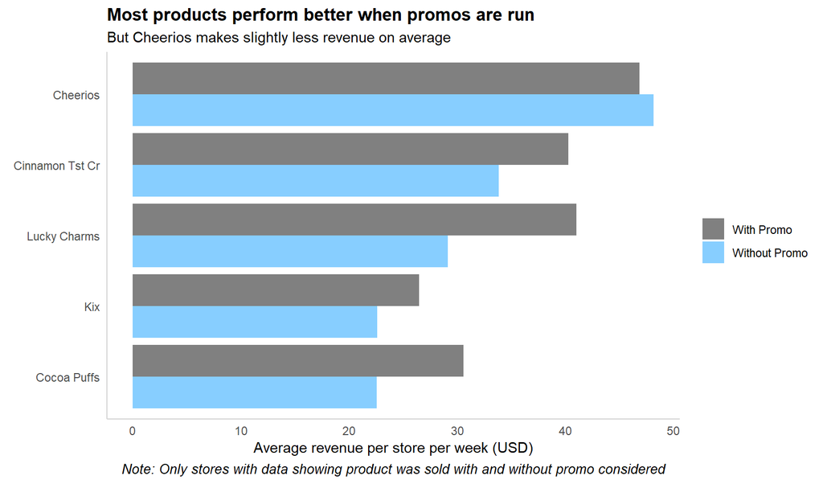

```r
# average revenue per store per week, with promo v/s without
# this only considers stores where data shows sales with AND without promo
# this is because raw data is a sample of sales

promo_comp_gm <- prod_rev_promo %>%
  mutate(store_both_with_out =
           sum(promo == "With Promo") + sum(promo == "Without Promo")) %>%
  filter(store_both_with_out == 2) %>%
  select(-store_both_with_out) %>%
  group_by(product_name, promo) %>%
  summarise(avg_rev_per_store = mean(avg_revenue),
            avg_qty_per_store = mean(avg_units))

# bar plot showing average sales per store with and without promo

ggplot(
    data = promo_comp_gm,
    aes(x = factor(product_name, levels = rev(gen_mills_ranked)),
        y = avg_rev_per_store,
        fill = factor(promo, levels = c("Without Promo", "With Promo")))
  ) +
  geom_bar(stat = "identity", position = "dodge") +
  theme_minimal() +
  scale_x_discrete(name = element_blank()) +
  scale_y_continuous(name = "Average revenue per store per week (USD)") +
  scale_fill_manual(
    name = element_blank(),
    values = c(colour_blue_1, colour_grey_5)
  ) +
  guides(fill = guide_legend(reverse = TRUE)) +
  theme(
    plot.title = element_text(colour = "black", face = "bold", size = 13),
    plot.caption = element_text(face = "italic", size = 10, hjust = 0.5),
    panel.grid.major = element_blank(),
    panel.grid.minor = element_blank(),
    axis.line = element_line(colour = colour_grey_3)
  ) +
  ggtitle(label = "Most products perform better when promos are run",
          subtitle = "But Cheerios makes slightly less revenue on average") +
  labs(
    caption = "Note: Only stores with data showing product was sold with and without promo considered"
  ) +
  coord_flip()
```

**Conclusions**:

- All products made more money on average per week per store when promos were run
  - The exception is Cheerios
- This might mean one of two things:
  - Discounts were high (we don’t know the actual level of discount)
  - Demand didn’t increase by a larger percentage than the discount offered

```r
# T-TESTS

# we are comparing average revenue and units with and without promo
# like previous, we are only considering stores with data on both sales with and without promo

t_test_data_promo <- prod_rev_promo %>%
  inner_join(
    prod_rev_promo %>% mutate(
      store_both_with_out = sum(promo == "With Promo") + sum(promo == "Without Promo")
    ) %>%
      filter(store_both_with_out == 2)
    ) %>%
  select(-store_both_with_out) %>%
  group_by(product_name, store_nbr, promo) %>%
  summarise(avg_rev_per_store = mean(avg_revenue),
            avg_qty_per_store = mean(avg_units))

t_test_data_sls_promo <- t_test_data_promo %>% select(-avg_qty_per_store) %>%
  spread(promo, avg_rev_per_store) %>%
  rename(`Ran Promo` = `With Promo`, `No Promo` = `Without Promo`)
t_test_data_qty_promo <- t_test_data_promo %>% select(-avg_rev_per_store) %>%
  spread(promo, avg_qty_per_store) %>%
  rename(`Ran Promo` = `With Promo`, `No Promo` = `Without Promo`)
```

We can use t-tests to confirm to give the above findings statistical validity.

```r
# TWO (INDEPENDENT) SAMPLE T-TEST ON REVENUE

# CHEERIOS

test_sls_cheerios <- t_test_data_sls_promo %>% filter(product_name == "Cheerios")
t.test(test_sls_cheerios$`Ran Promo`, test_sls_cheerios$`No Promo`,
       paired = FALSE, conf.level=0.95)
```

```
##
##  Welch Two Sample t-test
##
## data:  test_sls_cheerios$`Ran Promo` and test_sls_cheerios$`No Promo`
## t = -0.38218, df = 235.98, p-value = 0.7027
## alternative hypothesis: true difference in means is not equal to 0
## 95 percent confidence interval:
##  -8.108903  5.473908
## sample estimates:
## mean of x mean of y
##  46.85106  48.16856
```

```r
# CINNAMON TOAST CRUNCH

test_sls_cinntstcrch <- t_test_data_sls_promo %>% filter(product_name == "Cinnamon Tst Cr")
t.test(test_sls_cinntstcrch$`Ran Promo`, test_sls_cinntstcrch$`No Promo`,
       paired = FALSE, conf.level=0.95)
```

```
##
##  Welch Two Sample t-test
##
## data:  test_sls_cinntstcrch$`Ran Promo` and test_sls_cinntstcrch$`No Promo`
## t = 2.5278, df = 309.47, p-value = 0.01197
## alternative hypothesis: true difference in means is not equal to 0
## 95 percent confidence interval:
##   1.426822 11.450278
## sample estimates:
## mean of x mean of y
##  40.29734  33.85879
```

```r
# LUCKY CHARMS

test_sls_luckycharms <- t_test_data_sls_promo %>% filter(product_name == "Lucky Charms")
t.test(test_sls_luckycharms$`Ran Promo`, test_sls_luckycharms$`No Promo`,
       paired = FALSE, conf.level=0.95)
```

```
##
##  Welch Two Sample t-test
##
## data:  test_sls_luckycharms$`Ran Promo` and test_sls_luckycharms$`No Promo`
## t = 5.1606, df = 302.93, p-value = 4.46e-07
## alternative hypothesis: true difference in means is not equal to 0
## 95 percent confidence interval:
##   7.332671 16.371352
## sample estimates:
## mean of x mean of y
##  41.00602  29.15401
```

```r
# KIX

test_sls_kix <- t_test_data_sls_promo %>% filter(product_name == "Kix")
t.test(test_sls_kix$`Ran Promo`, test_sls_kix$`No Promo`,
       paired = FALSE, conf.level=0.95)
```

```
##
##  Welch Two Sample t-test
##
## data:  test_sls_kix$`Ran Promo` and test_sls_kix$`No Promo`
## t = 1.4143, df = 174.89, p-value = 0.1591
## alternative hypothesis: true difference in means is not equal to 0
## 95 percent confidence interval:
##  -1.538103  9.315744
## sample estimates:
## mean of x mean of y
##  26.47455  22.58573
```

```r
# COCOA PUFFS

test_sls_cocoapuffs <- t_test_data_sls_promo %>% filter(product_name == "Cocoa Puffs")
t.test(test_sls_cocoapuffs$`Ran Promo`, test_sls_cocoapuffs$`No Promo`,
       paired = FALSE, conf.level=0.95)
```

```
##
##  Welch Two Sample t-test
##
## data:  test_sls_cocoapuffs$`Ran Promo` and test_sls_cocoapuffs$`No Promo`
## t = 2.8689, df = 180.69, p-value = 0.00461
## alternative hypothesis: true difference in means is not equal to 0
## 95 percent confidence interval:
##   2.507654 13.555963
## sample estimates:
## mean of x mean of y
##  30.59339  22.56158
```

**Conclusions:**

- We can say that average revenue increased when promos were run, for Cinnamon Toast Crunch, Lucky Charms and Cocoa Puffs
- We do not have enough evidence of the same with the other products

Since promos involve discounting, we also need to see how effective the promos were in increasing demand, in terms of **units sold**.

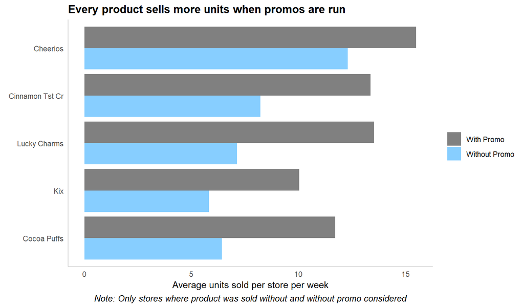

```r
# bar plot showing average units per store with and without promo

ggplot(
    data = promo_comp_gm,
    aes(x = factor(product_name, levels = rev(gen_mills_ranked)),
        y = avg_qty_per_store,
        fill = factor(promo, levels = c("Without Promo", "With Promo")))
  ) +
  geom_bar(stat = "identity", position = "dodge") +
  theme_minimal() +
  scale_x_discrete(name = element_blank()) +
  scale_y_continuous(name = "Average units sold per store per week") +
  scale_fill_manual(
    name = element_blank(),
    values = c(colour_blue_1, colour_grey_5)
  ) +
  guides(fill = guide_legend(reverse = TRUE)) +
  theme(
    plot.title = element_text(colour = "black", face = "bold", size = 13),
    plot.caption = element_text(face = "italic", size = 10, hjust = 0.5),
    panel.grid.major = element_blank(),
    panel.grid.minor = element_blank(),
    axis.line = element_line(colour = colour_grey_3)
  ) +
  ggtitle(label = "Every product sells more units when promos are run") +
  labs(
    caption = "Note: Only stores where product was sold without and without promo considered"
  ) +
  coord_flip()
```

**Conclusions**:

- We can see that units sold is higher on average when promos are run.
- Fall in average sales for Cheerios may indicate high discounts being offered
  - We do not know the actual level of discounts so we cannot say for sure

We can use t-tests to confirm the findings above.

```r
# CHEERIOS

test_qty_cheerios <- t_test_data_qty_promo %>% filter(product_name == "Cheerios")
t.test(test_qty_cheerios$`Ran Promo`, test_qty_cheerios$`No Promo`,
       paired = FALSE, conf.level=0.95)
```

```
##
##  Welch Two Sample t-test
##
## data:  test_qty_cheerios$`Ran Promo` and test_qty_cheerios$`No Promo`
## t = 3.6257, df = 235, p-value = 0.0003533
## alternative hypothesis: true difference in means is not equal to 0
## 95 percent confidence interval:
##  1.460627 4.936852
## sample estimates:
## mean of x mean of y
##  15.50280  12.30406
```

```r
# CINNAMON TOAST CRUNCH

test_qty_cinntstcrch <- t_test_data_qty_promo %>% filter(product_name == "Cinnamon Tst Cr")
t.test(test_qty_cinntstcrch$`Ran Promo`, test_qty_cinntstcrch$`No Promo`,
       paired = FALSE, conf.level=0.95)
```

```
##
##  Welch Two Sample t-test
##
## data:  test_qty_cinntstcrch$`Ran Promo` and test_qty_cinntstcrch$`No Promo`
## t = 7.2757, df = 301.56, p-value = 2.997e-12
## alternative hypothesis: true difference in means is not equal to 0
## 95 percent confidence interval:
##  3.749672 6.530029
## sample estimates:
## mean of x mean of y
## 13.366453  8.226603
```

```r
# LUCKY CHARMS

test_qty_luckycharms <- t_test_data_qty_promo %>% filter(product_name == "Lucky Charms")
t.test(test_qty_luckycharms$`Ran Promo`, test_qty_luckycharms$`No Promo`,
       paired = FALSE, conf.level=0.95)
```

```
##
##  Welch Two Sample t-test
##
## data:  test_qty_luckycharms$`Ran Promo` and test_qty_luckycharms$`No Promo`
## t = 9.5519, df = 275.97, p-value < 2.2e-16
## alternative hypothesis: true difference in means is not equal to 0
## 95 percent confidence interval:
##  5.086909 7.727998
## sample estimates:
## mean of x mean of y
## 13.537267  7.129814
```

```r
# KIX

test_qty_kix <- t_test_data_qty_promo %>% filter(product_name == "Kix")
t.test(test_qty_kix$`Ran Promo`, test_qty_kix$`No Promo`,
       paired = FALSE, conf.level=0.95)
```

```
##
##  Welch Two Sample t-test
##
## data:  test_qty_kix$`Ran Promo` and test_qty_kix$`No Promo`
## t = 4.7862, df = 154.12, p-value = 3.95e-06
## alternative hypothesis: true difference in means is not equal to 0
## 95 percent confidence interval:
##  2.477709 5.960494
## sample estimates:
## mean of x mean of y
## 10.044944  5.825843
```

```r
# COCOA PUFFS

test_qty_cocoapuffs <- t_test_data_qty_promo %>% filter(product_name == "Cocoa Puffs")
t.test(test_qty_cocoapuffs$`Ran Promo`, test_qty_cocoapuffs$`No Promo`,
       paired = FALSE, conf.level=0.95)
```

```
##
##  Welch Two Sample t-test
##
## data:  test_qty_cocoapuffs$`Ran Promo` and test_qty_cocoapuffs$`No Promo`
## t = 5.2042, df = 166.15, p-value = 5.687e-07
## alternative hypothesis: true difference in means is not equal to 0
## 95 percent confidence interval:
##  3.287438 7.306534
## sample estimates:
## mean of x mean of y
## 11.716312  6.419326
```

**Conclusions:**

There is enough evidence that *promos have helped increase quantity demanded* for all of our products. This tallies with the previous graph.

## 14.7 Are ads effective?

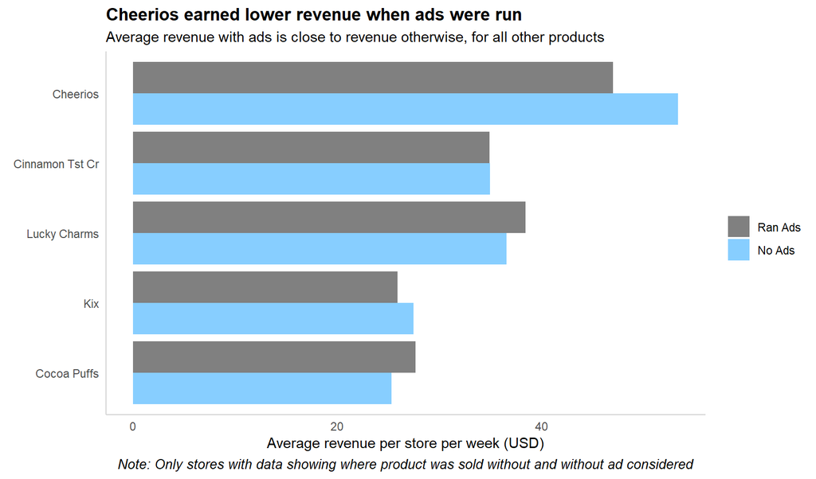

```r
brand_focus <- "General Mills"

# average revenue per store per week, with ad v/s without
# this only considers stores where data shows sales with AND without ad
# this is because raw data is a sample of sales

prod_rev_ad <- cereal %>%
  filter(brand_name == brand_focus) %>%
  mutate(ran_ad = (ad != "None")) %>%
  group_by(product_name, store_nbr, ran_ad) %>%
  summarise(avg_revenue = mean(sales), avg_units = mean(units))

ad_store_with_out_comp <- prod_rev_ad %>%
  mutate(store_with_out_ad = if_else(sum(ran_ad) == 1, "Ran Ads", "No Ads")) %>%
  group_by(product_name, store_with_out_ad) %>%
  summarise(avg_rev_per_store = mean(avg_revenue),
            avg_qty_per_store = mean(avg_units))

# bar plot showing average sales per store with and without promo

ggplot(
    data = ad_store_with_out_comp,
    aes(x = factor(product_name, levels = rev(gen_mills_ranked)),
        y = avg_rev_per_store, fill = store_with_out_ad)
  ) +
  geom_bar(stat = "identity", position = "dodge") +
  theme_minimal() +
  scale_x_discrete(name = element_blank()) +
  scale_y_continuous(name = "Average revenue per store per week (USD)") +
  scale_fill_manual(
    name = element_blank(),
    values = c(colour_blue_1, colour_grey_5)
  ) +
  guides(fill = guide_legend(reverse = TRUE)) +
  theme(
    plot.title = element_text(colour = "black", face = "bold", size = 13),
    plot.caption = element_text(face = "italic", size = 10, hjust = 0.5),
    panel.grid.major = element_blank(),
    panel.grid.minor = element_blank(),
    axis.line = element_line(colour = colour_grey_3)
  ) +
  ggtitle(label = "Cheerios earned lower revenue when ads were run",
          subtitle = "Average revenue with ads is close to revenue otherwise, for all other products") +
  labs(
    caption = "Note: Only stores with data showing where product was sold without and without ad considered"
  ) +
  coord_flip()
```

**Conclusions:**

- Cheerios loses revenue, on average, when they run ads too.
  - This could be influenced by promos being run at the same time, along with ads.
- Other products make the same amount, on average

```r
# Prepare data for t-tests

t_test_data_ad <- prod_rev_ad %>%
  inner_join(
    prod_rev_ad %>%
      mutate(store_with_out_ad = sum(ran_ad)) %>%
      filter(store_with_out_ad == 1) %>%
      select(product_name, store_nbr)) %>%
  group_by(product_name, store_nbr, ran_ad) %>%
  summarise(avg_rev_per_store = mean(avg_revenue),
            avg_qty_per_store = mean(avg_units))

t_test_data_sls_ad <- t_test_data_ad %>% select(-avg_qty_per_store) %>%
  spread(ran_ad, avg_rev_per_store) %>%
  rename(`Ran Ad` = `TRUE`, `No Ad` = `FALSE`)
t_test_data_qty_ad <- t_test_data_ad %>% select(-avg_rev_per_store) %>%
  spread(ran_ad, avg_qty_per_store) %>%
  rename(`Ran Ad` = `TRUE`, `No Ad` = `FALSE`)
```

We can use t-tests to confirm the findings above. First we do this with revenue.

```r
# CHEERIOS

test_sls_cheerios <- t_test_data_sls_ad %>% filter(product_name == "Cheerios")
t.test(test_sls_cheerios$`Ran Ad`, test_sls_cheerios$`No Ad`,
       paired = FALSE, conf.level=0.95)
```

```
##
##  Welch Two Sample t-test
##
## data:  test_sls_cheerios$`Ran Ad` and test_sls_cheerios$`No Ad`
## t = 1.5001, df = 166.84, p-value = 0.1355
## alternative hypothesis: true difference in means is not equal to 0
## 95 percent confidence interval:
##  -1.803496 13.214513
## sample estimates:
## mean of x mean of y
##  49.22265  43.51714
```

```r
# CINNAMON TOAST CRUNCH

test_sls_cinntstcrch <- t_test_data_sls_ad %>% filter(product_name == "Cinnamon Tst Cr")
t.test(test_sls_cinntstcrch$`Ran Ad`, test_sls_cinntstcrch$`No Ad`,
       paired = FALSE, conf.level=0.95)
```

```
##
##  Welch Two Sample t-test
##
## data:  test_sls_cinntstcrch$`Ran Ad` and test_sls_cinntstcrch$`No Ad`
## t = 0.69795, df = 211.79, p-value = 0.486
## alternative hypothesis: true difference in means is not equal to 0
## 95 percent confidence interval:
##  -3.663489  7.679813
## sample estimates:
## mean of x mean of y
##  35.72309  33.71492
```

```r
# LUCKY CHARMS

test_sls_luckycharms <- t_test_data_sls_ad %>% filter(product_name == "Lucky Charms")
t.test(test_sls_luckycharms$`Ran Ad`, test_sls_luckycharms$`No Ad`,
       paired = FALSE, conf.level=0.95)
```

```
##
##  Welch Two Sample t-test
##
## data:  test_sls_luckycharms$`Ran Ad` and test_sls_luckycharms$`No Ad`
## t = 1.655, df = 238.65, p-value = 0.09923
## alternative hypothesis: true difference in means is not equal to 0
## 95 percent confidence interval:
##  -0.9084648 10.4568262
## sample estimates:
## mean of x mean of y
##  40.30126  35.52707
```

```r
# KIX

test_sls_kix <- t_test_data_sls_ad %>% filter(product_name == "Kix")
t.test(test_sls_kix$`Ran Ad`, test_sls_kix$`No Ad`,
       paired = FALSE, conf.level=0.95)
```

```
##
##  Welch Two Sample t-test
##
## data:  test_sls_kix$`Ran Ad` and test_sls_kix$`No Ad`
## t = 1.3962, df = 101.46, p-value = 0.1657
## alternative hypothesis: true difference in means is not equal to 0
## 95 percent confidence interval:
##  -1.95648 11.25616
## sample estimates:
## mean of x mean of y
##  27.49341  22.84357
```

```r
# COCOA PUFFS

test_sls_cocoapuffs <- t_test_data_sls_ad %>% filter(product_name == "Cocoa Puffs")
t.test(test_sls_cocoapuffs$`Ran Ad`, test_sls_cocoapuffs$`No Ad`,
       paired = FALSE, conf.level=0.95)
```

```
##
##  Welch Two Sample t-test
##
## data:  test_sls_cocoapuffs$`Ran Ad` and test_sls_cocoapuffs$`No Ad`
## t = 1.9345, df = 135.27, p-value = 0.05514
## alternative hypothesis: true difference in means is not equal to 0
## 95 percent confidence interval:
##  -0.1207789 10.9413757
## sample estimates:
## mean of x mean of y
##  29.58049  24.17019
```

**Conclusions:**

- We don’t have enough evidence to show any product gained more revenue when ads are run
- This is inn contrast to promos that were shown to be effective for certain products, at least.

This may be because of price based marketing having a bigger impact on customer purchase behaviour.

We need to look at **units sold** too

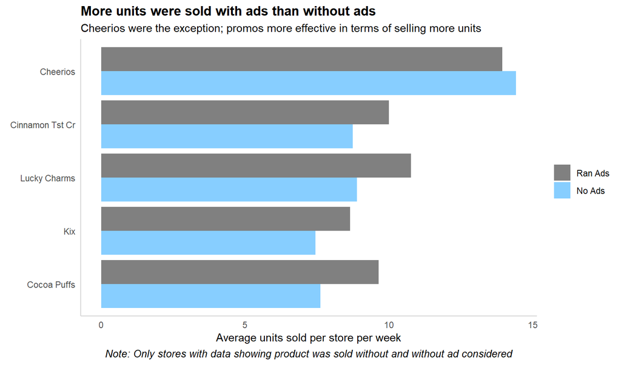

```r
ggplot(
  data = ad_store_with_out_comp,
  aes(x = factor(product_name, levels = rev(gen_mills_ranked)),
      y = avg_qty_per_store, fill = store_with_out_ad)
) +
  geom_bar(stat = "identity", position = "dodge") +
  theme_minimal() +
  scale_x_discrete(name = element_blank()) +
  scale_y_continuous(name = "Average units sold per store per week") +
  scale_fill_manual(
    name = element_blank(),
    values = c(colour_blue_1, colour_grey_5)
  ) +
  guides(fill = guide_legend(reverse = TRUE)) +
  theme(
    plot.title = element_text(colour = "black", face = "bold", size = 13),
    plot.caption = element_text(face = "italic", size = 10, hjust = 0.5),
    panel.grid.major = element_blank(),
    panel.grid.minor = element_blank(),
    axis.line = element_line(colour = colour_grey_3)
  ) +
  ggtitle(label = "More units were sold with ads than without ads",
          subtitle = "Cheerios were the exception; promos more effective in terms of selling more units") +
  labs(
    caption = "Note: Only stores with data showing product was sold without and without ad considered"
  ) +
  coord_flip()
```

**Conclusions:** All products except Cheerios sell more units with ad than without in the same store (the difference is minimal w.r.t Cheerios)

We can use t-tests to confirm the findings above. We have done this with revenue earlier; we need to do the same with units too.

```r
# CHEERIOS

test_qty_cheerios <- t_test_data_qty_ad %>% filter(product_name == "Cheerios")
t.test(test_qty_cheerios$`Ran Ad`, test_qty_cheerios$`No Ad`,
       paired = FALSE, conf.level=0.95)
```

```
##
##  Welch Two Sample t-test
##
## data:  test_qty_cheerios$`Ran Ad` and test_qty_cheerios$`No Ad`
## t = 2.8853, df = 178.28, p-value = 0.004393
## alternative hypothesis: true difference in means is not equal to 0
## 95 percent confidence interval:
##  0.9122776 4.8603340
## sample estimates:
## mean of x mean of y
##  15.06723  12.18092
```

```r
# CINNAMON TOAST CRUNCH

test_qty_cinntstcrch <- t_test_data_qty_ad %>% filter(product_name == "Cinnamon Tst Cr")
t.test(test_qty_cinntstcrch$`Ran Ad`, test_qty_cinntstcrch$`No Ad`,
       paired = FALSE, conf.level=0.95)
```

```
##
##  Welch Two Sample t-test
##
## data:  test_qty_cinntstcrch$`Ran Ad` and test_qty_cinntstcrch$`No Ad`
## t = 3.803, df = 255.55, p-value = 0.0001789
## alternative hypothesis: true difference in means is not equal to 0
## 95 percent confidence interval:
##  1.430128 4.501833
## sample estimates:
## mean of x mean of y
## 11.196774  8.230794
```

```r
# LUCKY CHARMS

test_qty_luckycharms <- t_test_data_qty_ad %>% filter(product_name == "Lucky Charms")
t.test(test_qty_luckycharms$`Ran Ad`, test_qty_luckycharms$`No Ad`,
       paired = FALSE, conf.level=0.95)
```

```
##
##  Welch Two Sample t-test
##
## data:  test_qty_luckycharms$`Ran Ad` and test_qty_luckycharms$`No Ad`
## t = 4.1914, df = 248.87, p-value = 3.855e-05
## alternative hypothesis: true difference in means is not equal to 0
## 95 percent confidence interval:
##  1.760234 4.880974
## sample estimates:
## mean of x mean of y
## 12.055556  8.734951
```

```r
# KIX

test_qty_kix <- t_test_data_qty_ad %>% filter(product_name == "Kix")
t.test(test_qty_kix$`Ran Ad`, test_qty_kix$`No Ad`,
       paired = FALSE, conf.level=0.95)
```

```
##
##  Welch Two Sample t-test
##
## data:  test_qty_kix$`Ran Ad` and test_qty_kix$`No Ad`
## t = 4.1265, df = 154.51, p-value = 6.002e-05
## alternative hypothesis: true difference in means is not equal to 0
## 95 percent confidence interval:
##  2.011404 5.705682
## sample estimates:
## mean of x mean of y
##  9.957958  6.099415
```

```r
# COCOA PUFFS

test_qty_cocoapuffs <- t_test_data_qty_ad %>% filter(product_name == "Cocoa Puffs")
t.test(test_qty_cocoapuffs$`Ran Ad`, test_qty_cocoapuffs$`No Ad`,
       paired = FALSE, conf.level=0.95)
```

```
##
##  Welch Two Sample t-test
##
## data:  test_qty_cocoapuffs$`Ran Ad` and test_qty_cocoapuffs$`No Ad`
## t = 3.6461, df = 155.72, p-value = 0.0003625
## alternative hypothesis: true difference in means is not equal to 0
## 95 percent confidence interval:
##  1.662939 5.595068
## sample estimates:
## mean of x mean of y
## 10.910569  7.281566
```

**Conclusions:** The tests show that more units are being sold while ads were run.

## 14.8 Are promos and ads together effective?

Since this is a sample of sales, we will compare average behaviour across all stores to understand the impact of running promos and ads together

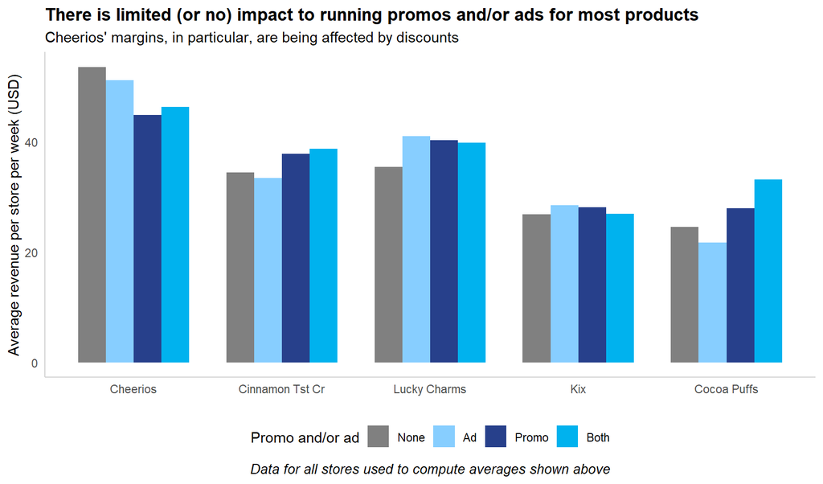

```r
# sales by product by store
# based on whether they ran just an ad, a promo or both

rev_comp_promo_plus_ad <- cereal %>%
  filter(brand_name == brand_focus) %>%
  group_by(product_name, store_nbr, promo_plus_ad) %>%
  summarise(avg_revenue = mean(sales), avg_units = mean(units)) %>%
  ungroup()

# sales by product (grouped further)
# based on whether they ran just an ad, a promo or both

promo_ad_plus_comp <- rev_comp_promo_plus_ad %>%
  group_by(product_name, promo_plus_ad) %>%
  summarise(avg_rev_per_store = mean(avg_revenue),
            avg_qty_per_store = mean(avg_units))

promo_levels <- c("None", "Ad", "Promo", "Both")

# bar plot showing average sales with promo, ad, both or none

memo_plot_1 <- ggplot(
    data = promo_ad_plus_comp,
    aes(x = factor(product_name, levels = gen_mills_ranked),
        y = avg_rev_per_store,
        fill = factor(promo_plus_ad, levels = promo_levels))
  ) +
  geom_bar(stat = "identity", position = "dodge", width = 0.75) +
  theme_minimal() +
  scale_x_discrete(name = element_blank()) +
  scale_y_continuous(name = "Average revenue per store per week (USD)") +
  scale_fill_manual(
    name = "Promo and/or ad",
    values = c(colour_grey_5, colour_blue_1, colour_blue_5, colour_blue_4)
  ) +
  guides(fill = guide_legend(reverse = FALSE)) +
  theme(
    plot.title = element_text(colour = "black", face = "bold", size = 13),
    plot.caption = element_text(face = "italic", size = 10, hjust = 0.5),
    panel.grid.major = element_blank(),
    panel.grid.minor = element_blank(),
    axis.line = element_line(colour = colour_grey_3),
    legend.position = "bottom"
  ) +
  ggtitle(label = "There is limited (or no) impact to running promos and/or ads for most products",
          subtitle = "Cheerios' margins, in particular, are being affected by discounts") +
  labs(
    caption = "Data for all stores used to compute averages shown above"
  )

memo_plot_1
```

**Conclusions:**

- Promos with/without ads together drive higher average sales (or at least breaking even) for:
  - Cinnamon Toast Crunch
  - Lucky Charms
  - Cocoa Puffs
- The same does not hold good for Cheerios
  - Running a promo with/without an ad is specially problematic
  - This may be because of discounting cutting margins

We need to check if the same holds true for units.

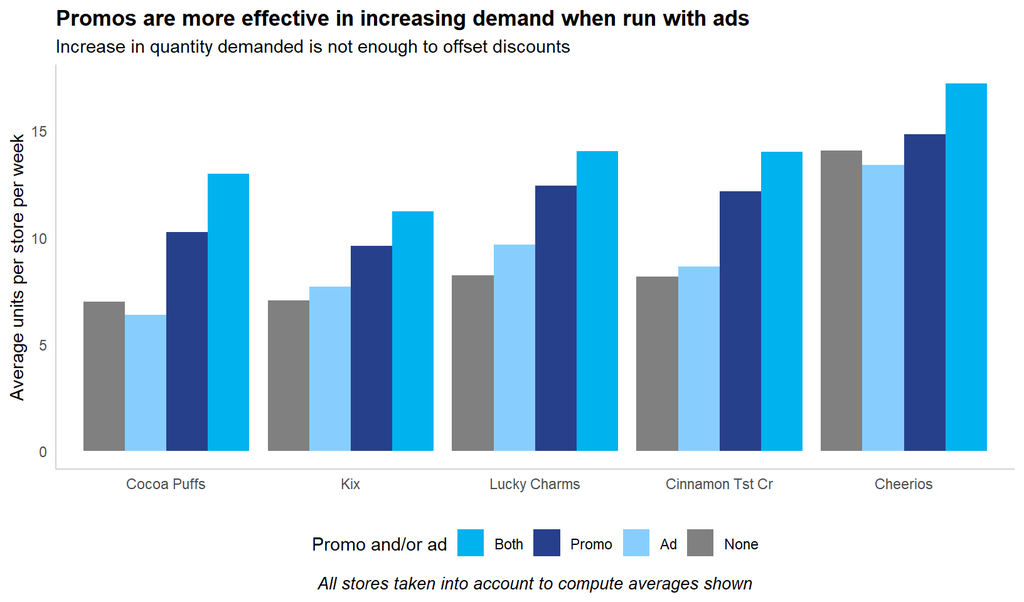

```r
# bar plot showing average units with promo, ad, both or none

memo_plot_2 <- ggplot(
  data = promo_ad_plus_comp,
  aes(x = factor(product_name, levels = rev(gen_mills_ranked)),
      y = avg_qty_per_store,
      fill = factor(promo_plus_ad, levels = promo_levels))
) +
  geom_bar(stat = "identity", position = "dodge") +
  theme_minimal() +
  scale_x_discrete(name = element_blank()) +
  scale_y_continuous(name = "Average units per store per week") +
  scale_fill_manual(
    name = "Promo and/or ad",
    values = c(colour_grey_5, colour_blue_1, colour_blue_5, colour_blue_4)
  ) +
  guides(fill = guide_legend(reverse = TRUE)) +
  theme(
    plot.title = element_text(colour = "black", face = "bold", size = 13),
    plot.caption = element_text(face = "italic", size = 10, hjust = 0.5),
    panel.grid.major = element_blank(),
    panel.grid.minor = element_blank(),
    axis.line = element_line(colour = colour_grey_3),
    legend.position = "bottom"
  ) +
  ggtitle(label = "Promos are more effective in increasing demand when run with ads",
          subtitle = "Increase in quantity demanded is not enough to offset discounts") +
  labs(
    caption = "All stores taken into account to compute averages shown"
  )

memo_plot_2
```

**Conclusions:**

- Promos and ads are driving up demand as shown by units sold
- But looking at revenue comparisons, it seems like increase in demand is not enough to break even w.r.t Cheerios

### 14.8.1 Do our findings have statistical validity?

Following points are important in our estimation of models:

- Models are run on log sales as sales does not follow a normal distribution
- We have included the following variables as they are the main questions of interest that can be influenced by General Mills:
  - promo: implying if a sale has included an promo
  - ad: implying if a sale has included an ad
  - promo * ad: this interaction term tells us if a promo and ad was run together.
- The following variables have not been included:
  - package: a product cannot change its packaging easily
  - flavor: a product cannot change its flavor easily
  - volume: a product cannot change its volume easily
  - brand_name: we are running separate models for every product, limited to General Mills
  - units: jointly determined with revenue
  - price: jointly determined with revenue
- Data includes all stores
- Models are being run separately for revenue and units
  - This is to assess the impact of promos and/or ads on both variables
- Our hypotheses:
  - Running promos or ads helps increase demand (by way of units sold), with promos and ads together being more effective.
  - But, promos, esp are affecting margins due to the discounts included.

```r
# MODELING

model_data <- cereal %>%
  select(brand_name, product_name, store_nbr, sales, units, promo, ad) %>%
  # inner_join(prod_rev_promo %>% select(product_name, store_nbr) %>% unique(),
  #            by = c("product_name", "store_nbr")) %>%
  mutate(ad = if_else(ad == "None", "Without Ad", "With Ad")) %>%
  mutate(ad = factor(ad, levels = c("Without Ad", "With Ad"))) %>%
  select(-store_nbr)

model_data$promo <- relevel(model_data$promo, ref = "Without Promo")
model_data$ad <- relevel(model_data$ad, ref = "Without Ad")

model_data_gm_sls <- model_data %>%
  filter(brand_name == "General Mills") %>%
  select(-brand_name, -units)
model_data_gm_qty <- model_data %>%
  filter(brand_name == "General Mills") %>%
  select(-brand_name, -sales)

# CONSTRUCT SALES MODELS

sales_model_gm_cheerios <- lm(data = model_data_gm_sls %>%
        filter(product_name == "Cheerios") %>% select(-product_name),
        log(sales) ~ . + promo * ad)
sales_model_gm_cinntstcrch <- lm(data = model_data_gm_sls %>%
        filter(product_name == "Cinnamon Tst Cr") %>% select(-product_name),
        log(sales) ~ . + promo * ad)
sales_model_gm_luckycharms <- lm(data = model_data_gm_sls %>%
        filter(product_name == "Lucky Charms") %>% select(-product_name),
        log(sales) ~ . + promo * ad)
sales_model_gm_kix <- lm(data = model_data_gm_sls %>%
        filter(product_name == "Kix") %>% select(-product_name),
        log(sales) ~ . + promo * ad)
sales_model_gm_cocoapuffs <- lm(data = model_data_gm_sls %>%
        filter(product_name == "Cocoa Puffs") %>% select(-product_name),
        log(sales) ~ . + promo * ad)

# CONSTRUCT UNITS MODELS

units_model_gm_cheerios <- lm(data = model_data_gm_qty %>%
          filter(product_name == "Cheerios") %>% select(-product_name),
        log(units) ~ . + promo * ad)
units_model_gm_cinntstcrch <- lm(data = model_data_gm_qty %>%
        filter(product_name == "Cinnamon Tst Cr") %>% select(-product_name),
        log(units) ~ . + promo * ad)
units_model_gm_luckycharms <- lm(data = model_data_gm_qty %>%
        filter(product_name == "Lucky Charms") %>% select(-product_name),
        log(units) ~ . + promo * ad)
units_model_gm_kix <- lm(data = model_data_gm_qty %>%
        filter(product_name == "Kix") %>% select(-product_name),
        log(units) ~ . + promo * ad)
units_model_gm_cocoapuffs <- lm(data = model_data_gm_qty %>%
        filter(product_name == "Cocoa Puffs") %>% select(-product_name),
        log(units) ~ . + promo * ad)
```

```r
summary(sales_model_gm_cheerios)
```

```
##
## Call:
## lm(formula = log(sales) ~ . + promo * ad, data = model_data_gm_sls %>%
##     filter(product_name == "Cheerios") %>% select(-product_name))
##
## Residuals:
##     Min      1Q  Median      3Q     Max
## -4.1589 -0.3217  0.1940  0.5998  1.2807
##
## Coefficients:
##                             Estimate Std. Error t value Pr(>|t|)
## (Intercept)                3.7160679  0.0246506 150.749  < 2e-16 ***
## promoWith Promo           -0.2503020  0.0699060  -3.581 0.000354 ***
## adWith Ad                  0.0008431  0.1030171   0.008 0.993471
## promoWith Promo:adWith Ad  0.2257866  0.1689741   1.336 0.181686
## ---
## Signif. codes:  0 '***' 0.001 '**' 0.01 '*' 0.05 '.' 0.1 ' ' 1
##
## Residual standard error: 0.8428 on 1454 degrees of freedom
## Multiple R-squared:  0.008807,   Adjusted R-squared:  0.006762
## F-statistic: 4.307 on 3 and 1454 DF,  p-value: 0.004933
```

```r
summary(units_model_gm_cheerios)
```

```
##
## Call:
## lm(formula = log(units) ~ . + promo * ad, data = model_data_gm_qty %>%
##     filter(product_name == "Cheerios") %>% select(-product_name))
##
## Residuals:
##     Min      1Q  Median      3Q     Max
## -2.7585 -0.3517  0.1338  0.5133  0.9796
##
## Coefficients:
##                           Estimate Std. Error t value Pr(>|t|)
## (Intercept)                2.43112    0.02100 115.781   <2e-16 ***
## promoWith Promo            0.03548    0.05955   0.596   0.5514
## adWith Ad                 -0.07848    0.08775  -0.894   0.3713
## promoWith Promo:adWith Ad  0.37037    0.14393   2.573   0.0102 *
## ---
## Signif. codes:  0 '***' 0.001 '**' 0.01 '*' 0.05 '.' 0.1 ' ' 1
##
## Residual standard error: 0.7179 on 1454 degrees of freedom
## Multiple R-squared:  0.00796,    Adjusted R-squared:  0.005913
## F-statistic: 3.889 on 3 and 1454 DF,  p-value: 0.008791
```

**Conclusions:**

- The model tallies with previous graphs and shows that running promos without ads is problematic
  - Running a promo without an ad reduces revenue by 25%, as against not having any marketing (either promo or ad)
- Running promos and ads together has a significant effect on quantity demanded (here, 37%)
  - But, given discounts offered, it may still not be enough to help increase revenue
  - Model for log(sales) proves that

```r
summary(sales_model_gm_cinntstcrch)
```

```
##
## Call:
## lm(formula = log(sales) ~ . + promo * ad, data = model_data_gm_sls %>%
##     filter(product_name == "Cinnamon Tst Cr") %>% select(-product_name))
##
## Residuals:
##     Min      1Q  Median      3Q     Max
## -3.3247 -0.5257  0.1385  0.6138  1.8437
##
## Coefficients:
##                           Estimate Std. Error t value Pr(>|t|)
## (Intercept)                3.19085    0.02265 140.886   <2e-16 ***
## promoWith Promo            0.13384    0.06296   2.126   0.0336 *
## adWith Ad                  0.03124    0.09688   0.322   0.7471
## promoWith Promo:adWith Ad  0.08753    0.14845   0.590   0.5555
## ---
## Signif. codes:  0 '***' 0.001 '**' 0.01 '*' 0.05 '.' 0.1 ' ' 1
##
## Residual standard error: 0.8633 on 1830 degrees of freedom
## Multiple R-squared:  0.005574,   Adjusted R-squared:  0.003944
## F-statistic: 3.419 on 3 and 1830 DF,  p-value: 0.01669
```

```r
summary(units_model_gm_cinntstcrch)
```

```
##
## Call:
## lm(formula = log(units) ~ . + promo * ad, data = model_data_gm_qty %>%
##     filter(product_name == "Cinnamon Tst Cr") %>% select(-product_name))
##
## Residuals:
##     Min      1Q  Median      3Q     Max
## -2.4450 -0.4487  0.1573  0.6093  1.5436
##
## Coefficients:
##                           Estimate Std. Error t value Pr(>|t|)
## (Intercept)                1.78858    0.02120  84.349  < 2e-16 ***
## promoWith Promo            0.45190    0.05894   7.667 2.84e-14 ***
## adWith Ad                  0.10038    0.09070   1.107    0.269
## promoWith Promo:adWith Ad  0.10409    0.13899   0.749    0.454
## ---
## Signif. codes:  0 '***' 0.001 '**' 0.01 '*' 0.05 '.' 0.1 ' ' 1
##
## Residual standard error: 0.8083 on 1830 degrees of freedom
## Multiple R-squared:  0.05234,    Adjusted R-squared:  0.05079
## F-statistic: 33.69 on 3 and 1830 DF,  p-value: < 2.2e-16
```

**Conclusions:**

- Promos are effective both in terms of increase in quantity demanded as well as in revenue.
- The combined effect of running promos and ads together isn’t there for Cinnamon Toast Crunch.

```r
summary(sales_model_gm_luckycharms)
```

```
##
## Call:
## lm(formula = log(sales) ~ . + promo * ad, data = model_data_gm_sls %>%
##     filter(product_name == "Lucky Charms") %>% select(-product_name))
##
## Residuals:
##     Min      1Q  Median      3Q     Max
## -3.2787 -0.4986  0.1336  0.5992  1.5627
##
## Coefficients:
##                           Estimate Std. Error t value Pr(>|t|)
## (Intercept)                3.26865    0.02275 143.691  < 2e-16 ***
## promoWith Promo            0.19826    0.05958   3.328 0.000894 ***
## adWith Ad                  0.19840    0.09581   2.071 0.038537 *
## promoWith Promo:adWith Ad -0.24250    0.13868  -1.749 0.080543 .
## ---
## Signif. codes:  0 '***' 0.001 '**' 0.01 '*' 0.05 '.' 0.1 ' ' 1
##
## Residual standard error: 0.8167 on 1677 degrees of freedom
## Multiple R-squared:  0.009492,   Adjusted R-squared:  0.00772
## F-statistic: 5.357 on 3 and 1677 DF,  p-value: 0.001135
```

```r
summary(units_model_gm_luckycharms)
```

```
##
## Call:
## lm(formula = log(units) ~ . + promo * ad, data = model_data_gm_qty %>%
##     filter(product_name == "Lucky Charms") %>% select(-product_name))
##
## Residuals:
##     Min      1Q  Median      3Q     Max
## -2.4230 -0.4279  0.1317  0.5837  1.5180
##
## Coefficients:
##                           Estimate Std. Error t value Pr(>|t|)
## (Intercept)                1.81425    0.02219  81.756   <2e-16 ***
## promoWith Promo            0.49781    0.05812   8.565   <2e-16 ***
## adWith Ad                  0.20360    0.09347   2.178   0.0295 *
## promoWith Promo:adWith Ad -0.09270    0.13529  -0.685   0.4933
## ---
## Signif. codes:  0 '***' 0.001 '**' 0.01 '*' 0.05 '.' 0.1 ' ' 1
##
## Residual standard error: 0.7967 on 1677 degrees of freedom
## Multiple R-squared:  0.06416,    Adjusted R-squared:  0.06249
## F-statistic: 38.33 on 3 and 1677 DF,  p-value: < 2.2e-16
```

**Conclusions:**

- Promos without ads are effective in increasing both quantity demanded as well as revenue.
- Surprisingly, promos and ads together are shown to decrease revenue.
  - however, the log(sales) model shows that it is not statistically significant.

```r
summary(sales_model_gm_kix)
```

```
##
## Call:
## lm(formula = log(sales) ~ . + promo * ad, data = model_data_gm_sls %>%
##     filter(product_name == "Kix") %>% select(-product_name))
##
## Residuals:
##      Min       1Q   Median       3Q      Max
## -3.02170 -0.61057  0.07726  0.66421  1.94964
##
## Coefficients:
##                           Estimate Std. Error t value Pr(>|t|)
## (Intercept)                2.91597    0.02912 100.138   <2e-16 ***
## promoWith Promo            0.10573    0.08740   1.210    0.227
## adWith Ad                  0.12875    0.13861   0.929    0.353
## promoWith Promo:adWith Ad -0.15297    0.19002  -0.805    0.421
## ---
## Signif. codes:  0 '***' 0.001 '**' 0.01 '*' 0.05 '.' 0.1 ' ' 1
##
## Residual standard error: 0.8989 on 1192 degrees of freedom
## Multiple R-squared:  0.002153,   Adjusted R-squared:  -0.0003586
## F-statistic: 0.8572 on 3 and 1192 DF,  p-value: 0.4628
```

```r
summary(units_model_gm_kix)
```

```
##
## Call:
## lm(formula = log(units) ~ . + promo * ad, data = model_data_gm_qty %>%
##     filter(product_name == "Kix") %>% select(-product_name))
##
## Residuals:
##      Min       1Q   Median       3Q      Max
## -2.09298 -0.49406  0.01677  0.70992  1.73954
##
## Coefficients:
##                           Estimate Std. Error t value Pr(>|t|)
## (Intercept)               1.592669   0.028797  55.307  < 2e-16 ***
## promoWith Promo           0.333566   0.086431   3.859  0.00012 ***
## adWith Ad                 0.160240   0.137078   1.169  0.24265
## promoWith Promo:adWith Ad 0.006504   0.187909   0.035  0.97239
## ---
## Signif. codes:  0 '***' 0.001 '**' 0.01 '*' 0.05 '.' 0.1 ' ' 1
##
## Residual standard error: 0.889 on 1192 degrees of freedom
## Multiple R-squared:  0.02897,    Adjusted R-squared:  0.02652
## F-statistic: 11.85 on 3 and 1192 DF,  p-value: 1.188e-07
```

**Conclusions:**

- Promos, without ads, contribute to a significant increase in demand.
- But this does not seem to have an (statistically) significant impact on revenue

```r
summary(units_model_gm_cocoapuffs)
```

```
##
## Call:
## lm(formula = log(units) ~ . + promo * ad, data = model_data_gm_qty %>%
##     filter(product_name == "Cocoa Puffs") %>% select(-product_name))
##
## Residuals:
##      Min       1Q   Median       3Q      Max
## -2.35368 -0.47736  0.03347  0.69944  1.77662
##
## Coefficients:
##                           Estimate Std. Error t value Pr(>|t|)
## (Intercept)                1.57597    0.03283  48.010  < 2e-16 ***
## promoWith Promo            0.43264    0.07670   5.640  2.2e-08 ***
## adWith Ad                 -0.05676    0.14046  -0.404   0.6862
## promoWith Promo:adWith Ad  0.40183    0.18286   2.197   0.0282 *
## ---
## Signif. codes:  0 '***' 0.001 '**' 0.01 '*' 0.05 '.' 0.1 ' ' 1
##
## Residual standard error: 0.8851 on 1016 degrees of freedom
## Multiple R-squared:  0.07613,    Adjusted R-squared:  0.0734
## F-statistic: 27.91 on 3 and 1016 DF,  p-value: < 2.2e-16
```

```r
summary(sales_model_gm_cocoapuffs)
```

```
##
## Call:
## lm(formula = log(sales) ~ . + promo * ad, data = model_data_gm_sls %>%
##     filter(product_name == "Cocoa Puffs") %>% select(-product_name))
##
## Residuals:
##     Min      1Q  Median      3Q     Max
## -2.8656 -0.5544  0.1094  0.6481  1.7778
##
## Coefficients:
##                           Estimate Std. Error t value Pr(>|t|)
## (Intercept)                2.86408    0.03208  89.268   <2e-16 ***
## promoWith Promo            0.17526    0.07497   2.338   0.0196 *
## adWith Ad                 -0.07993    0.13729  -0.582   0.5606
## promoWith Promo:adWith Ad  0.31161    0.17873   1.744   0.0815 .
## ---
## Signif. codes:  0 '***' 0.001 '**' 0.01 '*' 0.05 '.' 0.1 ' ' 1
##
## Residual standard error: 0.8651 on 1016 degrees of freedom
## Multiple R-squared:  0.02086,    Adjusted R-squared:  0.01797
## F-statistic: 7.215 on 3 and 1016 DF,  p-value: 8.582e-05
```

**Conclusions:**

# 15 What we have learned

- Both promos and ads are effective in increasing demand (in terms of units)
  - Promos and ads together are even more effective
- For most products, revenue is either at similar levels or higher when promos and/or ads are run
- Cheerios is the exception
  - Cheerios is priced at a lower level
  - Hence, discounts offered through promos are cutting into margins
  - We don’t know how large discounts were, so they may have been larger than 5%

**Key takeaway:** *Promos and ads are effective in driving demand for all products, but it may be cutting margins for Cheerios, which is priced lower and is the top seller, due to discounts offered, while having a limited impact on revenue for other products. Hence, it may be prudent to review how much discount is being offered via promos, esp for Cheerios.*

```r
# Save work for the memo

save.image("sourabh-MidTermProj-Workspace.RData")
```